# Automatic Ticket Assignment

```python
import pandas as pd
import numpy as np
import seaborn as sns
import matplotlib.pyplot as plt

%matplotlib inline
```

```python
# Load the data

data = pd.read_excel('input_data.xls')
```

```python
data.head()
```

|  | Short description | Description | Caller | Assignment group |
| --- | --- | --- | --- | --- |
| 0 | login issue | -verified user details.(employee# & manager na... | spxjnwir pjlcoqds | GRP_0 |
| 1 | outlook | \r\n\r\nreceived from: hmjdrvpb.komuaywn@gmail... | hmjdrvpb komuaywn | GRP_0 |
| 2 | cant log in to vpn | \r\n\r\nreceived from: eylqgodm.ybqkwiam@gmail... | eylqgodm ybqkwiam | GRP_0 |
| 3 | unable to access hr_tool page | unable to access hr_tool page | xbkucsvz gcpydteq | GRP_0 |
| 4 | skype error | skype error | owlgqjme qhcozdfx | GRP_0 |

```python
# Understand data structure
data.info()
```

```
<class 'pandas.core.frame.DataFrame'>
RangeIndex: 8500 entries, 0 to 8499
Data columns (total 4 columns):
 #   Column             Non-Null Count  Dtype
---  ------             --------------  -----
 0   Short description  8492 non-null   object
 1   Description        8499 non-null   object
 2   Caller             8500 non-null   object
 3   Assignment group   8500 non-null   object
dtypes: object(4)
memory usage: 265.8+ KB
```

**Looks like there are missing values in short description and description columns**

```python
# Check missing values in short description
data[data['Short description'].isna()]
```

|  | Short description | Description | Caller | Assignment group |
| --- | --- | --- | --- | --- |
| 2604 | NaN | \r\n\r\nreceived from: ohdrnswl.rezuibdt@gmail... | ohdrnswl rezuibdt | GRP_34 |
| 3383 | NaN | \r\n-connected to the user system using teamvi... | qftpazns fxpnytmk | GRP_0 |
| 3906 | NaN | -user unable tologin to vpn.\r\n-connected to... | awpcmsey ctdiuqwe | GRP_0 |
| 3910 | NaN | -user unable tologin to vpn.\r\n-connected to... | rhwsmefo tvphyura | GRP_0 |
| 3915 | NaN | -user unable tologin to vpn.\r\n-connected to... | hxripljo efzounig | GRP_0 |
| 3921 | NaN | -user unable tologin to vpn.\r\n-connected to... | cziadygo veiosxby | GRP_0 |
| 3924 | NaN | name:wvqgbdhm fwchqjor\nlanguage:\nbrowser:mic... | wvqgbdhm fwchqjor | GRP_0 |
| 4341 | NaN | \r\n\r\nreceived from: eqmuniov.ehxkcbgj@gmail... | eqmuniov ehxkcbgj | GRP_0 |

```python
# Check missing values in Description
data[data['Description'].isna()]
```

|  | Short description | Description | Caller | Assignment group |
| --- | --- | --- | --- | --- |
| 4395 | i am locked out of skype | NaN | viyglzfo ajtfzpkb | GRP_0 |

```python
# We see that there is no case where both short description and description are NaN.
# We will later create a field which will be a combination of short description and description, so for now, we replace nan
# in both short description and description with empty string

data.fillna(value='', inplace=True)
```

```python
# No. of unique values in all columns

for col in data.columns:
    print(f"{col}: {data[col].nunique()}")
```

```
Short description: 7482
Description: 7818
Caller: 2950
Assignment group: 74
```

```python
# Caller does not seem to have any impact on the ticket assigment hence we'll proceed with dropping

data.drop('Caller', axis=1, inplace=True)
```

```python
# Check duplicate values
len(data.drop_duplicates())
```

```
7909
```

```python
copy_df = data.copy()
duplicates = copy_df[copy_df.duplicated()]
print('Number of duplicates are {}'.format(len(duplicates)))
duplicates
```

```
Number of duplicates are 591
```

|  | Short description | Description | Assignment group |
| --- | --- | --- | --- |
| 51 | call for ecwtrjnq jpecxuty | call for ecwtrjnq jpecxuty | GRP_0 |
| 81 | erp SID_34 account locked | erp SID_34 account locked | GRP_0 |
| 123 | unable to display expense report | unable to display expense report | GRP_0 |
| 157 | ess password reset | ess password reset | GRP_0 |
| 229 | call for ecwtrjnq jpecxuty | call for ecwtrjnq jpecxuty | GRP_0 |
| ... | ... | ... | ... |
| 8424 | windows account lockout | windows account lockout | GRP_0 |
| 8450 | unable to connect to wifi | unable to connect to wifi | GRP_0 |
| 8451 | password reset erp SID_34 | password reset erp SID_34 | GRP_0 |
| 8458 | windows account locked | windows account locked | GRP_0 |
| 8489 | account locked | account locked | GRP_0 |

591 rows × 3 columns

```python
# There are duplicate values, drop them...
data.drop_duplicates(inplace=True)
```

```python
# Distribution of tickets among assignment groups
dist = data[['Assignment group', 'Description']].groupby(by='Assignment group').agg('count') \
    .rename(columns={'Description': 'Num tickets'}).reset_index().sort_values(by='Num tickets', ascending=False)
dist.head(10)
```

|  | Assignment group | Num tickets |
| --- | --- | --- |
| 0 | GRP_0 | 3429 |
| 72 | GRP_8 | 645 |
| 17 | GRP_24 | 285 |
| 4 | GRP_12 | 256 |
| 73 | GRP_9 | 252 |
| 12 | GRP_2 | 241 |
| 11 | GRP_19 | 214 |
| 23 | GRP_3 | 200 |
| 56 | GRP_6 | 183 |
| 5 | GRP_13 | 145 |

```python
dist["count_perc"] = round((dist["Num tickets"]/data.shape[0])*100,2)
dist.sort_values(["count_perc"], axis=0,
                 ascending=False, inplace=True)
dist.head()
```

|  | Assignment group | Num tickets | count_perc |
| --- | --- | --- | --- |
| 0 | GRP_0 | 3429 | 43.36 |
| 72 | GRP_8 | 645 | 8.16 |
| 17 | GRP_24 | 285 | 3.60 |
| 4 | GRP_12 | 256 | 3.24 |
| 73 | GRP_9 | 252 | 3.19 |

```python
#Cumulative analysis
cum_dist  = dist.copy()
cum_dist['Cumulative Num Tickets'] = cum_dist['Num tickets'].cumsum()
cum_dist['Cumulative Perc'] = cum_dist['count_perc'].cumsum()
```

```python
cum_dist.head(10)
```

|  | Assignment group | Num tickets | count_perc | Cumulative Num Tickets | Cumulative Perc |
| --- | --- | --- | --- | --- | --- |
| 0 | GRP_0 | 3429 | 43.36 | 3429 | 43.36 |
| 72 | GRP_8 | 645 | 8.16 | 4074 | 51.52 |
| 17 | GRP_24 | 285 | 3.60 | 4359 | 55.12 |
| 4 | GRP_12 | 256 | 3.24 | 4615 | 58.36 |
| 73 | GRP_9 | 252 | 3.19 | 4867 | 61.55 |
| 12 | GRP_2 | 241 | 3.05 | 5108 | 64.60 |
| 11 | GRP_19 | 214 | 2.71 | 5322 | 67.31 |
| 23 | GRP_3 | 200 | 2.53 | 5522 | 69.84 |
| 56 | GRP_6 | 183 | 2.31 | 5705 | 72.15 |
| 5 | GRP_13 | 145 | 1.83 | 5850 | 73.98 |

There are a few assignment groups which have very less tickets

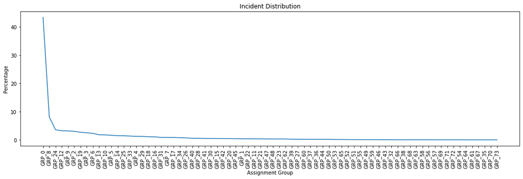

```python
# Let's visualize their distribution

plt.subplots(figsize = (18,5))
plt.plot(dist["Assignment group"], dist["count_perc"])
plt.xlabel('Assignment Group')
plt.ylabel('Percentage')
plt.title('Incident Distribution')
plt.xticks(rotation=90)
plt.show()
```

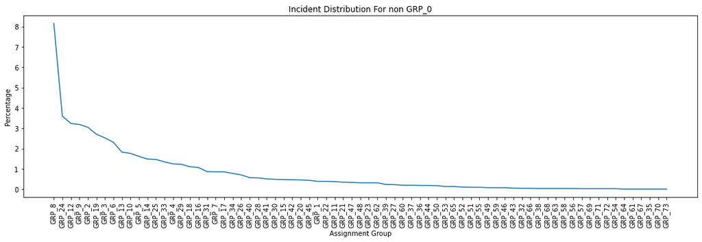

```python
## View the Distribution of only records that don't belong to GRP_0
df_test = dist[dist["Assignment group"] != 'GRP_0']
plt.subplots(figsize = (18,5))

plt.plot(df_test["Assignment group"], df_test["count_perc"])
plt.xlabel('Assignment Group')
plt.ylabel('Percentage')
plt.xticks(rotation=90)

plt.title('Incident Distribution For non GRP_0')

plt.show()
```

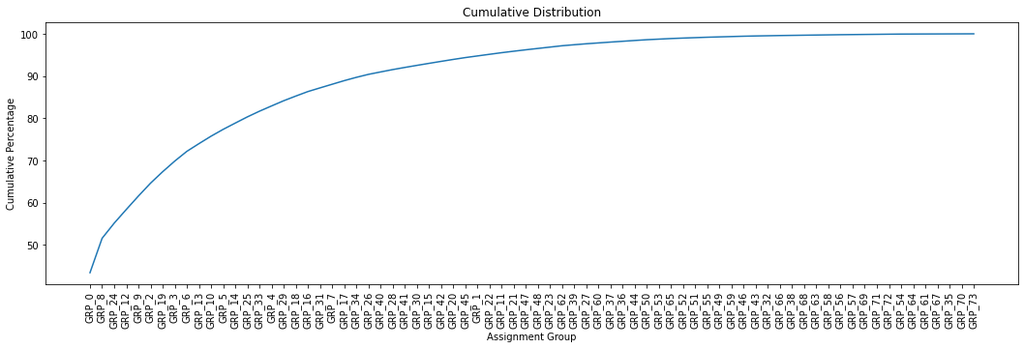

```python
## View the Cumulative Distribution
df_test = cum_dist
plt.subplots(figsize = (18,5))

plt.plot(df_test["Assignment group"], df_test["Cumulative Perc"])
plt.xlabel('Assignment Group')
plt.ylabel('Cumulative Percentage')
plt.xticks(rotation=90)

plt.title('Cumulative Distribution')

plt.show()
```

```python
# We can see a clear elbow at grp_30 and we will classify all further groups into a misc group because they don't have much sample to train.

cum_dist[cum_dist['Assignment group']=='GRP_30']
```

|  | Assignment group | Num tickets | count_perc | Cumulative Num Tickets | Cumulative Perc |
| --- | --- | --- | --- | --- | --- |
| 24 | GRP_30 | 39 | 0.49 | 7319 | 92.55 |

```python
# Identify all the assignment groups which have no more than 39 tickets
dist[dist['Num tickets'] <= 39]
print('Groups having number of tickets less than 39 are : {}'.format(len(dist[dist['Num tickets'] <= 39])))
```

```
Groups having number of tickets less than 39 are : 47
```

```python
# We can merge above groups into a misc group
short_groups = dist[dist['Num tickets'] <= 39]['Assignment group'].unique()
data['Assignment group'] = data['Assignment group'].apply(lambda x: 'GRP_MISC' if x in short_groups else x)
data['Assignment group'].value_counts()
```

```
GRP_0       3429
GRP_8        645
GRP_MISC     629
GRP_24       285
GRP_12       256
GRP_9        252
GRP_2        241
GRP_19       214
GRP_3        200
GRP_6        183
GRP_13       145
GRP_10       140
GRP_5        128
GRP_14       118
GRP_25       116
GRP_33       107
GRP_4         99
GRP_29        97
GRP_18        88
GRP_16        85
GRP_31        69
GRP_7         68
GRP_17        68
GRP_34        62
GRP_26        56
GRP_40        45
GRP_28        44
GRP_41        40
Name: Assignment group, dtype: int64
```

```python
#Left over assignment groups
data['Assignment group'].nunique()
```

```
28
```

```python
data.head()
```

|  | Short description | Description | Assignment group |
| --- | --- | --- | --- |
| 0 | login issue | -verified user details.(employee# & manager na... | GRP_0 |
| 1 | outlook | \r\n\r\nreceived from: hmjdrvpb.komuaywn@gmail... | GRP_0 |
| 2 | cant log in to vpn | \r\n\r\nreceived from: eylqgodm.ybqkwiam@gmail... | GRP_0 |
| 3 | unable to access hr_tool page | unable to access hr_tool page | GRP_0 |
| 4 | skype error | skype error | GRP_0 |

```python
# Check whether description is equal to Short Description
data[data['Short description'] == data['Description']]
```

|  | Short description | Description | Assignment group |
| --- | --- | --- | --- |
| 3 | unable to access hr_tool page | unable to access hr_tool page | GRP_0 |
| 4 | skype error | skype error | GRP_0 |
| 5 | unable to log in to engineering tool and skype | unable to log in to engineering tool and skype | GRP_0 |
| 7 | ticket_no1550391- employment status - new non-... | ticket_no1550391- employment status - new non-... | GRP_0 |
| 8 | unable to disable add ins on outlook | unable to disable add ins on outlook | GRP_0 |
| ... | ... | ... | ... |
| 8486 | ticket update on ticket_no0427635 | ticket update on ticket_no0427635 | GRP_0 |
| 8492 | hr_tool etime option not visitble | hr_tool etime option not visitble | GRP_0 |
| 8494 | tablet needs reimaged due to multiple issues w... | tablet needs reimaged due to multiple issues w... | GRP_3 |
| 8496 | telephony_software issue | telephony_software issue | GRP_0 |
| 8497 | vip2: windows password reset for tifpdchb pedx... | vip2: windows password reset for tifpdchb pedx... | GRP_0 |

2348 rows × 3 columns

```python
# Combine Short description and Description to create a final column
import re

def combine_all(row):
    # return short desc +  description
    final_string = row['Description']

    # Add short description if not exactly similar to description
    if row['Short description'] != row['Description']:
        final_string = f"{row['Short description']} {final_string}"

    return final_string

data['final_description'] = data.apply(combine_all, axis=1)
```

```python
data.head()
```

|  | Short description | Description | Assignment group | final_description |
| --- | --- | --- | --- | --- |
| 0 | login issue | -verified user details.(employee# & manager na... | GRP_0 | login issue -verified user details.(employee# ... |
| 1 | outlook | \r\n\r\nreceived from: hmjdrvpb.komuaywn@gmail... | GRP_0 | outlook \r\n\r\nreceived from: hmjdrvpb.komuay... |
| 2 | cant log in to vpn | \r\n\r\nreceived from: eylqgodm.ybqkwiam@gmail... | GRP_0 | cant log in to vpn \r\n\r\nreceived from: eylq... |
| 3 | unable to access hr_tool page | unable to access hr_tool page | GRP_0 | unable to access hr_tool page |
| 4 | skype error | skype error | GRP_0 | skype error |

```python
# Now we can select only final_description and Assgignment group
data = data[['final_description', 'Assignment group']]
data.head()
```

|  | final_description | Assignment group |
| --- | --- | --- |
| 0 | login issue -verified user details.(employee# ... | GRP_0 |
| 1 | outlook \r\n\r\nreceived from: hmjdrvpb.komuay... | GRP_0 |
| 2 | cant log in to vpn \r\n\r\nreceived from: eylq... | GRP_0 |
| 3 | unable to access hr_tool page | GRP_0 |
| 4 | skype error | GRP_0 |

```python
# Now we notice that their are tickets in other languages as well (like German etc)
# Because we will be building vocabulary and getting embedings for a single language,
# we need to take care of other languages...

# We will use pycld2 library to perform language detection
#! pip install https://github.com/aboSamoor/pycld2/zipball/e3ac86ed4d4902e912691c1531d0c5645382a726
```

```python
# We create a function which will use above library to detect the prominent language
import pycld2 as cld

def detect_prominent_lang(row):
    # Remove '\'
    description = row['final_description'].replace('\\', '')
    # Ascii encode description
    description = description.encode(encoding='ascii', errors='replace')
    isReliable, textBytesFound, details = cld.detect(description)
    return details[0][0]

# Get the languages in a new column
data['language'] = data.apply(detect_prominent_lang, axis=1)
data.head()
```

|  | final_description | Assignment group | language |
| --- | --- | --- | --- |
| 0 | login issue -verified user details.(employee# ... | GRP_0 | ENGLISH |
| 1 | outlook \r\n\r\nreceived from: hmjdrvpb.komuay... | GRP_0 | ENGLISH |
| 2 | cant log in to vpn \r\n\r\nreceived from: eylq... | GRP_0 | ENGLISH |
| 3 | unable to access hr_tool page | GRP_0 | ENGLISH |
| 4 | skype error | GRP_0 | LATIN |

```python
# Lets see the distribution of languages
lang_dist = data[['language', 'final_description']].groupby(by='language').agg('count') \
    .rename(columns={'final_description': 'Num tickets'}).reset_index().sort_values(by='Num tickets', ascending=False)
# Add pct
lang_dist["count_perc"] = round((lang_dist["Num tickets"]/data.shape[0])*100,2)
dist.sort_values(["count_perc"], axis=0, ascending=False, inplace=True)
# Add cummulative pct
cum_lang_dist  = lang_dist.copy()
cum_lang_dist['Cumulative Num Tickets'] = cum_lang_dist['Num tickets'].cumsum()
cum_lang_dist['Cumulative Perc'] = cum_lang_dist['count_perc'].cumsum()
cum_lang_dist.sort_values(by='count_perc', ascending=False)
```

|  | language | Num tickets | count_perc | Cumulative Num Tickets | Cumulative Perc |
| --- | --- | --- | --- | --- | --- |
| 2 | ENGLISH | 7146 | 90.35 | 7146 | 90.35 |
| 11 | Unknown | 396 | 5.01 | 7542 | 95.36 |
| 4 | GERMAN | 341 | 4.31 | 7883 | 99.67 |
| 8 | PORTUGUESE | 10 | 0.13 | 7893 | 99.80 |
| 6 | LATIN | 5 | 0.06 | 7898 | 99.86 |
| 0 | DANISH | 2 | 0.03 | 7900 | 99.89 |
| 7 | POLISH | 2 | 0.03 | 7902 | 99.92 |
| 9 | SPANISH | 2 | 0.03 | 7904 | 99.95 |
| 1 | DUTCH | 1 | 0.01 | 7905 | 99.96 |
| 3 | GALICIAN | 1 | 0.01 | 7906 | 99.97 |
| 5 | INTERLINGUA | 1 | 0.01 | 7907 | 99.98 |
| 10 | TURKISH | 1 | 0.01 | 7908 | 99.99 |
| 12 | WARAY_PHILIPPINES | 1 | 0.01 | 7909 | 100.00 |

As we can see, Most of the data is captured in either ENGLISH, GERMAN or Unknown language.  
Let's see what does Unknown group looks like...

```python
data[data.language=='Unknown'].head(10)
```

|  | final_description | Assignment group | language |
| --- | --- | --- | --- |
| 39 | call for ecwtrjnq jpecxuty | GRP_0 | Unknown |
| 126 | blank call //gso | GRP_0 | Unknown |
| 146 | erp_print_tool install. | GRP_0 | Unknown |
| 148 | install acrobat standard | GRP_0 | Unknown |
| 211 | insurance information | GRP_0 | Unknown |
| 222 | support fÃ¼r fa.gstry \arexjftu ohxdwngl suppo... | GRP_24 | Unknown |
| 230 | blank call | GRP_0 | Unknown |
| 255 | probleme mit laufwerk z: \laeusvjo fvaihgpx | GRP_24 | Unknown |
| 302 | EU_tool ist sehr langsadgtym \ywqgrbnx jwnsyzb... | GRP_24 | Unknown |
| 304 | alte eq abholen \wrcktgbd wzrgyunp | GRP_24 | Unknown |

It seems that some of them are English, some are German but they somehow were not detected properly by pycld2. (upon deeper inspection of all the rows, we see there are few non-ascii descriptions which are all gibberish)  
It would be good if we can try to translate the German + Unknown group to English which enables us to keep > 99.5% of the data

```python
# We install google_trans_new API (https://github.com/lushan88a/google_trans_new)
# Note: We are not using the widely used googletrans API as at the time of writing this code, it was broken.

! pip install google_trans_new
```

```python
from google_trans_new import google_translator

# Create translator object
translator = google_translator()

# We translate only the German and unknown group and
# create a new trans_final_description column which contains translated text
data['trans_final_description'] = data.apply(lambda row: translator.translate(row.final_description, lang_tgt='en')
                                       if row.language in ['GERMAN', 'Unknown'] else row.final_description, axis=1)

# Lets have a look at few of the translations
data[data['language'].isin(['GERMAN', 'Unknown'])].head(10)
```

|  | final_description | Assignment group | language | trans_final_description |
| --- | --- | --- | --- | --- |
| 39 | call for ecwtrjnq jpecxuty | GRP_0 | Unknown | call for ecwtrjnq jpecxuty |
| 126 | blank call //gso | GRP_0 | Unknown | blank call //gso |
| 146 | erp_print_tool install. | GRP_0 | Unknown | erp_print_tool install. |
| 148 | install acrobat standard | GRP_0 | Unknown | install acrobat standard |
| 211 | insurance information | GRP_0 | Unknown | insurance information |
| 222 | support für fa.gstry \arexjftu ohxdwngl suppo... | GRP_24 | Unknown | support für fa.gstry \arexjftu ohxdwngl suppo... |
| 223 | probleme mit bluescreen . hallo ,\n\nes ist er... | GRP_24 | GERMAN | problems with bluescreen. Hi there , it happe... |
| 230 | blank call | GRP_0 | Unknown | blank call |
| 255 | probleme mit laufwerk z: \laeusvjo fvaihgpx | GRP_24 | Unknown | problems with drive z: \ laeusvjo fvaihgpx |
| 270 | neues passwort für accountname tgryhu hgygrtu... | GRP_0 | GERMAN | new password for account name tgryhu hgygrtui ... |

This seems to have worked well and it translated words with accented chars as well...  
Now we only keep rows with language as English, German or Unknown (as they have been converted)  
Note: The gibberish descriptions' translation will still be gibberish, but they will be removed in data-preprocessing stage

```python
# Keep the rows in English, German or Unknown and keep necessary columns
data = data[data.language.isin(['ENGLISH', 'GERMAN', 'Unknown'])][['trans_final_description', 'Assignment group']] \
    .rename(columns={'trans_final_description': 'final_description'})
data.head()
```

|  | final_description | Assignment group |
| --- | --- | --- |
| 0 | login issue -verified user details.(employee# ... | GRP_0 |
| 1 | outlook \r\n\r\nreceived from: hmjdrvpb.komuay... | GRP_0 |
| 2 | cant log in to vpn \r\n\r\nreceived from: eylq... | GRP_0 |
| 3 | unable to access hr_tool page | GRP_0 |
| 5 | unable to log in to engineering tool and skype | GRP_0 |

```python
print(f"So our final dataset has {len(data)} rows...")
```

```
So our final dataset has 7883 rows...
```

### Data Preprocessing

We perform following pre-processing:

- Replace non-ascii characters with '?'
- Remove:
  - HTML tags + image content placeholders
  - Punctuations + Digits + line-break, carriage returns etc
  - Stopwords + common mail words
- Lemmatization

```python
import re
import nltk
from string import punctuation
from nltk import word_tokenize
from nltk.corpus import wordnet,stopwords
from nltk.stem import WordNetLemmatizer

# Replaces non-ascii characters with '?' which will be removed in next step
data['proc_final_description'] = data['final_description'].apply(lambda x: x.encode(encoding='ascii',
                                                                                    errors='replace').decode())

# define stopwords and common mail words
stop_words = stopwords.words('english')
stop_words = stop_words + ['hi','hello','com','gmail','cc','regards','thanks', 'date',
                           'from', 'subject', 'sent', 'ic', 'cc', 'bcc', 'outlook']

# define html tags and image content placeholder regex
html_image_cnt_tags = re.compile('<.*?>|(\[)?[a-zA-Z0-9_.+:-]+@[a-zA-Z0-9-]+\.[a-zA-Z0-9-.]{2,8}(\])?')

# define punctuation + digits + line-breaks regex
puncs = re.compile("""[!"#$%&'()*\\\+,-.\/:;\]\[<=>?@^_`{|}~\d\n\r\t]""")

def clean_text(text):

    # Remove HTML tags and image content placeholders
    text = text.lower()
    text = re.sub(html_image_cnt_tags, ' ', text)

    # Remove punctuation + digits + line-breaks
    text = re.sub(puncs, ' ', text) # Replace all punctuations with ' ', so words can still be tokenized properly

    # Remove stop words and common mail words
    words = word_tokenize(text)
    words = [w for w in words if w not in stop_words]
    sentence = ' '.join(words)

    return sentence

data['proc_final_description'] = data['proc_final_description'].apply(clean_text)
data.head()
```

|  | final_description | Assignment group | proc_final_description |
| --- | --- | --- | --- |
| 0 | login issue -verified user details.(employee# ... | GRP_0 | login issue verified user details employee man... |
| 1 | outlook \r\n\r\nreceived from: hmjdrvpb.komuay... | GRP_0 | received team meetings skype meetings etc appe... |
| 2 | cant log in to vpn \r\n\r\nreceived from: eylq... | GRP_0 | cant log vpn received log vpn best |
| 3 | unable to access hr_tool page | GRP_0 | unable access hr tool page |
| 5 | unable to log in to engineering tool and skype | GRP_0 | unable log engineering tool skype |

```python
# Define Lemmatize functions (will help to significantly reduce the vocabulary)

nltk.download('wordnet')
nltk.download('averaged_perceptron_tagger')

lemmatizer = WordNetLemmatizer()

def nltk_tag_to_wordnet_tag(nltk_tag):
    if nltk_tag.startswith('J'):
        return wordnet.ADJ
    elif nltk_tag.startswith('V'):
        return wordnet.VERB
    elif nltk_tag.startswith('N'):
        return wordnet.NOUN
    elif nltk_tag.startswith('R'):
        return wordnet.ADV
    else:
        return None

def lemmatize_words(sentence):
    #tokenize the sentence and find the POS tag for each token
    nltk_tagged = nltk.pos_tag(nltk.word_tokenize(sentence))
    #tuple of (token, wordnet_tag)
    wordnet_tagged = map(lambda x: (x[0], nltk_tag_to_wordnet_tag(x[1])), nltk_tagged)
    lemmatized_sentence = []
    for word, tag in wordnet_tagged:
        if tag is None:
            #if there is no available tag, append the token as is
            lemmatized_sentence.append(word)
        else:
            #else use the tag to lemmatize the token
            lemmatized_sentence.append(lemmatizer.lemmatize(word, tag))
    return " ".join(lemmatized_sentence)
```

```python
# Lemmatize proc_final_description
data['proc_final_description'] = data['proc_final_description'].apply(lemmatize_words)
data.head()
```

|  | final_description | Assignment group | proc_final_description |
| --- | --- | --- | --- |
| 0 | login issue -verified user details.(employee# ... | GRP_0 | login issue verify user detail employee manage... |
| 1 | outlook \r\n\r\nreceived from: hmjdrvpb.komuay... | GRP_0 | receive team meeting skype meeting etc appear ... |
| 2 | cant log in to vpn \r\n\r\nreceived from: eylq... | GRP_0 | cant log vpn receive log vpn best |
| 3 | unable to access hr_tool page | GRP_0 | unable access hr tool page |
| 5 | unable to log in to engineering tool and skype | GRP_0 | unable log engineering tool skype |

```python
data.to_csv('clean_translated_data.csv', header=True, index=False)
```

```python
data = pd.read_csv('clean_translated_data.csv')
```

```python
data.head()
```

|  | final_description | Assignment group | proc_final_description |
| --- | --- | --- | --- |
| 0 | login issue -verified user details.(employee# ... | GRP_0 | login issue verify user detail employee manage... |
| 1 | outlook \r\n\r\nreceived from: hmjdrvpb.komuay... | GRP_0 | receive team meeting skype meeting etc appear ... |
| 2 | cant log in to vpn \r\n\r\nreceived from: eylq... | GRP_0 | cant log vpn receive log vpn best |
| 3 | unable to access hr_tool page | GRP_0 | unable access hr tool page |
| 4 | unable to log in to engineering tool and skype | GRP_0 | unable log engineering tool skype |

```python
# To help us decide the max length of the description to keep, we add a column having num_words
data['num_words'] = data['proc_final_description'].apply(lambda x: len(str(x).split()))
data.head()
```

|  | final_description | Assignment group | proc_final_description | num_words |
| --- | --- | --- | --- | --- |
| 0 | login issue -verified user details.(employee# ... | GRP_0 | login issue verify user detail employee manage... | 24 |
| 1 | outlook \r\n\r\nreceived from: hmjdrvpb.komuay... | GRP_0 | receive team meeting skype meeting etc appear ... | 13 |
| 2 | cant log in to vpn \r\n\r\nreceived from: eylq... | GRP_0 | cant log vpn receive log vpn best | 7 |
| 3 | unable to access hr_tool page | GRP_0 | unable access hr tool page | 5 |
| 4 | unable to log in to engineering tool and skype | GRP_0 | unable log engineering tool skype | 5 |

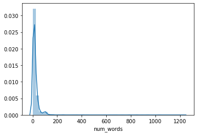

```python
# Visualize the distribution

sns.distplot(data.num_words)
```

```python
# Lets look at the mean number of words per assignment group

data_avg_length = pd.DataFrame(data.groupby('Assignment group').agg('mean')['num_words']) \
    .rename(columns={'num_words': 'avg_tkt_len'})
data_ticket_cnt = pd.DataFrame(data.groupby('Assignment group').agg('count')['num_words']) \
    .rename(columns={'num_words': 'ticket_cnt'})
data_avg_length.join(data_ticket_cnt).sort_values(by='avg_tkt_len', ascending=False)
```

| Assignment group | avg_tkt_len | ticket_cnt |
| --- | --- | --- |
| GRP_2 | 75.705394 | 241 |
| GRP_26 | 40.909091 | 55 |
| GRP_18 | 33.954545 | 88 |
| GRP_8 | 33.857364 | 645 |
| GRP_4 | 31.060606 | 99 |
| GRP_41 | 30.975000 | 40 |
| GRP_13 | 30.234483 | 145 |
| GRP_12 | 30.207031 | 256 |
| GRP_MISC | 29.691935 | 620 |
| GRP_14 | 27.694915 | 118 |
| GRP_40 | 26.866667 | 45 |
| GRP_16 | 26.623529 | 85 |
| GRP_29 | 26.082474 | 97 |
| GRP_25 | 25.000000 | 115 |
| GRP_3 | 23.735000 | 200 |
| GRP_10 | 22.207143 | 140 |
| GRP_19 | 20.345794 | 214 |
| GRP_33 | 20.299065 | 107 |
| GRP_5 | 19.718750 | 128 |
| GRP_7 | 19.264706 | 68 |
| GRP_28 | 18.272727 | 44 |
| GRP_34 | 18.096774 | 62 |
| GRP_6 | 17.005464 | 183 |
| GRP_9 | 16.579365 | 252 |
| GRP_0 | 14.635673 | 3420 |
| GRP_31 | 12.544118 | 68 |
| GRP_17 | 12.485294 | 68 |
| GRP_24 | 7.428571 | 280 |

As we can see, the average is varying with the assignment group, it should be safe to keep truncate/pad the tickets at length of 100 words

```python
# Set max_length to 100
max_len = 100
```

```python
data = pd.read_csv("clean_translated_data.csv")
data.head()
```

|  | final_description | Assignment group | proc_final_description |
| --- | --- | --- | --- |
| 0 | login issue -verified user details.(employee# ... | GRP_0 | login issue verify user detail employee manage... |
| 1 | outlook \r\n\r\nreceived from: hmjdrvpb.komuay... | GRP_0 | receive team meeting skype meeting etc appear ... |
| 2 | cant log in to vpn \r\n\r\nreceived from: eylq... | GRP_0 | cant log vpn receive log vpn best |
| 3 | unable to access hr_tool page | GRP_0 | unable access hr tool page |
| 4 | unable to log in to engineering tool and skype | GRP_0 | unable log engineering tool skype |

```python
# Keep only proc and assignment group
data = data.drop('final_description', axis=1)
data.head()
```

|  | Assignment group | proc_final_description |
| --- | --- | --- |
| 0 | GRP_0 | login issue verify user detail employee manage... |
| 1 | GRP_0 | receive team meeting skype meeting etc appear ... |
| 2 | GRP_0 | cant log vpn receive log vpn best |
| 3 | GRP_0 | unable access hr tool page |
| 4 | GRP_0 | unable log engineering tool skype |

```python
# The pre-processing performed has introduced some nans
# We need to remove them now

data.info()
```

```
<class 'pandas.core.frame.DataFrame'>
RangeIndex: 7883 entries, 0 to 7882
Data columns (total 2 columns):
 #   Column                  Non-Null Count  Dtype
---  ------                  --------------  -----
 0   Assignment group        7883 non-null   object
 1   proc_final_description  7840 non-null   object
dtypes: object(2)
memory usage: 123.3+ KB
```

```python
# Check missing values in proc_final_description
data[data['proc_final_description'].isna()].head()
```

|  | Assignment group | proc_final_description |
| --- | --- | --- |
| 1036 | GRP_MISC | NaN |
| 1125 | GRP_MISC | NaN |
| 1383 | GRP_MISC | NaN |
| 1617 | GRP_MISC | NaN |
| 1618 | GRP_MISC | NaN |

```python
# Check number of nulls
len(data[data['proc_final_description'].isna()])
```

```
43
```

```python
# Checking how many are from MISC group
nulls = data[data['proc_final_description'].isna()]
len(nulls[nulls['Assignment group'] == 'GRP_MISC'])
```

```
35
```

```python
# dropping off the nulls since maximum belong to GRP_MISC
data.dropna(inplace=True)
```

```python
# check for dupliactes after translation and lemmatization
data[data.duplicated()]
```

|  | Assignment group | proc_final_description |
| --- | --- | --- |
| 14 | GRP_0 | ticket update inplant |
| 39 | GRP_0 | ticket update inplant |
| 57 | GRP_8 | job mm zscr dly merktc fail job scheduler rece... |
| 66 | GRP_8 | job job fail job scheduler receive job job fai... |
| 67 | GRP_8 | job job fail job scheduler receive job job fai... |
| ... | ... | ... |
| 7835 | GRP_8 | abended job job scheduler job receive abended ... |
| 7844 | GRP_9 | abended job job scheduler job receive abended ... |
| 7846 | GRP_9 | abended job job scheduler job receive abended ... |
| 7850 | GRP_8 | abended job job scheduler bkwin hostname inc r... |
| 7870 | GRP_0 | ticket update ticket |

1110 rows × 2 columns

```python
# So a lot of duplicates after translation and lemmatization.
data.drop_duplicates(inplace=True)
```

```python
print(f"Final rows in data: {len(data)}")
```

```
Final rows in data: 6730
```

```python
# Check the number of distinct assignment groups
print(data['Assignment group'].unique())
print(data['Assignment group'].nunique())
```

```
['GRP_0' 'GRP_MISC' 'GRP_3' 'GRP_4' 'GRP_5' 'GRP_6' 'GRP_7' 'GRP_8'
 'GRP_9' 'GRP_10' 'GRP_12' 'GRP_13' 'GRP_14' 'GRP_16' 'GRP_17' 'GRP_18'
 'GRP_19' 'GRP_2' 'GRP_24' 'GRP_25' 'GRP_26' 'GRP_28' 'GRP_29' 'GRP_31'
 'GRP_33' 'GRP_34' 'GRP_40' 'GRP_41']
28
```

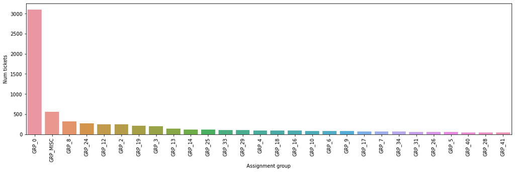

```python
# Visualize the distribution
dist = data[['Assignment group', 'proc_final_description']].groupby(by='Assignment group').agg('count') \
    .rename(columns={'proc_final_description': 'Num tickets'}).reset_index().sort_values(by='Num tickets', ascending=False)

plt.subplots(figsize = (18,5))
plt.xticks(rotation=90)
sns.barplot(x='Assignment group', y='Num tickets', data=dist)
```

```python
# We see that we still have 28 groups, making the data extremely skewed. For the purpose of modelling,
# It is best if we keep a max of 6 classes to predict

# Get top 6 groups (excluding grp_misc)
top_6_grps = dist[dist['Assignment group'] != 'GRP_MISC']['Assignment group'].unique()[:6]

# Keep records only having assignment in top 6 groups
data_top6 = data[data['Assignment group'].isin(top_6_grps)]
data_top6['Assignment group'].value_counts()
```

```
GRP_0     3102
GRP_8      320
GRP_24     271
GRP_12     246
GRP_2      241
GRP_19     214
Name: Assignment group, dtype: int64
```

```python
len(data_top6)
```

```
4394
```

```python
# We see that we still have 28 groups, making the data extremely skewed. For the purpose of modelling,
# It is best if we keep a max of 10 classes to predict

# Get top 10 groups (excluding grp_misc)
top_10_grps = dist[dist['Assignment group'] != 'GRP_MISC']['Assignment group'].unique()[:10]

# Keep records only having assignment in top 10 groups
data_top10 = data[data['Assignment group'].isin(top_10_grps)]
data_top10['Assignment group'].value_counts()
```

```
GRP_0     3102
GRP_8      320
GRP_24     271
GRP_12     246
GRP_2      241
GRP_19     214
GRP_3      200
GRP_13     142
GRP_14     118
GRP_25     115
Name: Assignment group, dtype: int64
```

```python
from sklearn.preprocessing import LabelEncoder

le = LabelEncoder()
# Label encode Assignment group
data['Assignment group'] = le.fit_transform(data['Assignment group'])

# Keep only relevant columns
data = data[['proc_final_description', 'Assignment group']]
data.head()
```

|  | proc_final_description | Assignment group |
| --- | --- | --- |
| 0 | login issue verify user detail employee manage... | 0 |
| 1 | receive team meeting skype meeting etc appear ... | 0 |
| 2 | cant log vpn receive log vpn best | 0 |
| 3 | unable access hr tool page | 0 |
| 4 | unable log engineering tool skype | 0 |

```python
# Label encode Assignment group
data_top6['Assignment group'] = le.fit_transform(data_top6['Assignment group'])

# Keep only relevant columns
data_top6 = data_top6[['proc_final_description', 'Assignment group']]
data_top6.head()
```

|  | proc_final_description | Assignment group |
| --- | --- | --- |
| 0 | login issue verify user detail employee manage... | 0 |
| 1 | receive team meeting skype meeting etc appear ... | 0 |
| 2 | cant log vpn receive log vpn best | 0 |
| 3 | unable access hr tool page | 0 |
| 4 | unable log engineering tool skype | 0 |

```python
# Label encode Assignment group
data_top10['Assignment group'] = le.fit_transform(data_top10['Assignment group'])

# Keep only relevant columns
data_top10 = data_top10[['proc_final_description', 'Assignment group']]
data_top10.head()
```

|  | proc_final_description | Assignment group |
| --- | --- | --- |
| 0 | login issue verify user detail employee manage... | 0 |
| 1 | receive team meeting skype meeting etc appear ... | 0 |
| 2 | cant log vpn receive log vpn best | 0 |
| 3 | unable access hr tool page | 0 |
| 4 | unable log engineering tool skype | 0 |

### Visualizing Word clouds for top 6 assignment groups

```python
!pip install wordcloud
```

```
You are using pip version 19.0.3, however version 20.3.3 is available.
```

```python
from wordcloud import WordCloud

# For generating wordcloud, we create a single string of words grouped by assignment groups
assign_groups = data_top6['Assignment group'].unique()

words_in_grp = dict()
for tup in data_top6.sort_values(by='Assignment group').itertuples(): # sort so that keys in dict are sorted

    # tup is of the form (Index, proc_final_description, Assignment group)
    if tup[2] not in words_in_grp:
        words_in_grp[tup[2]] = ""

    # Filter out words with less than 3 characters
    filtered_text = " ".join([word for word in tup[1].split() if len(word) > 2])

    words_in_grp[tup[2]] = f"{words_in_grp[tup[2]]} {filtered_text}"
```

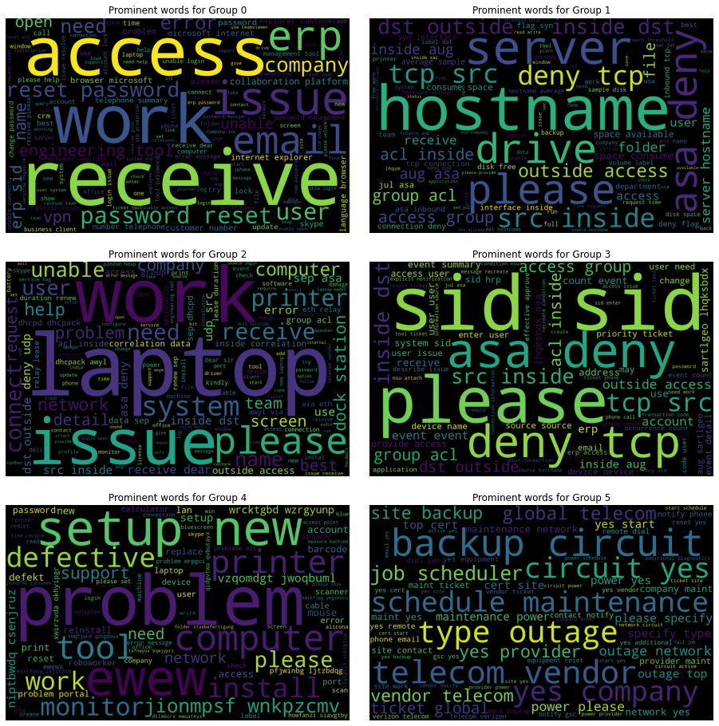

```python
# Generate and store wordcloud images
images = dict()

for grp in words_in_grp:
    images[grp] = WordCloud(width = 1280, height = 800, background_color ='black',
                            min_font_size = 15).generate(words_in_grp[grp])

# show images iteratively
f = plt.figure(figsize = (13, 13), facecolor=None)
for i, grp in enumerate(images):
    # Debug, plot figure
    f.add_subplot(3, len(images)/3, i+1)
    plt.imshow(images[grp])
    plt.axis("off")
    plt.tight_layout(pad=2)
    plt.title(f"Prominent words for Group {grp}")

plt.show(block=True)
```

## Model building starts

```python
from sklearn.model_selection import train_test_split

X = data['proc_final_description']
y = data['Assignment group']

X_train, X_test, y_train, y_test = train_test_split(X, y, test_size=0.3, stratify=y, random_state=12)
```

### Tf-idf with ML classifier

```python
from sklearn import feature_extraction, model_selection, naive_bayes, preprocessing, feature_selection, metrics

# initialize vectorizer with max vocab of 10000 words
vectorizer = feature_extraction.text.TfidfVectorizer(max_features=10000, ngram_range=(1,2))
```

```python
# Fit and transform the vectorizer on train set
X_train_tfidf_trans = vectorizer.fit_transform(X_train)

# Have a look at vectorizer vocabulary
vectorizer.vocabulary_['skype meeting']
```

```
8084
```

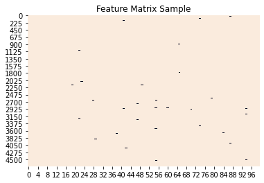

```python
# Visualize the feature matrix
sns.heatmap(X_train_tfidf_trans.todense()
            [:,np.random.randint(0,X_train_tfidf_trans.shape[1],100)]==0, vmin=0, vmax=1, cbar=False) \
    .set_title('Feature Matrix Sample')
```

```python
# Let's build a train a classifier on above data
# We will start with Multinomial Naive-Bayes
from sklearn.naive_bayes import MultinomialNB

# Define and train the model
classifier = MultinomialNB()
classifier.fit(X_train_tfidf_trans, y_train)

# transform the test set
X_test_tfidf_trans = vectorizer.transform(X_test)

# Make predictions
predicted = classifier.predict(X_test_tfidf_trans)
predicted_prob = classifier.predict_proba(X_test_tfidf_trans)
```

```python
## Accuracy, Precision, Recall
accuracy = metrics.accuracy_score(y_test, predicted)
auc = metrics.roc_auc_score(y_test, predicted_prob,
                            multi_class="ovr")
print("Accuracy:",  round(accuracy,2))
print("Auc:", round(auc,2))
print("Detail:")
print(metrics.classification_report(y_test, predicted))
```

```
Accuracy: 0.54
Auc: 0.8
Detail:
              precision    recall  f1-score   support

           0       0.51      1.00      0.68       931
           1       0.00      0.00      0.00        25
           2       0.79      0.20      0.32        74
           3       0.00      0.00      0.00        43
           4       1.00      0.06      0.11        35
           5       0.00      0.00      0.00        25
           6       0.00      0.00      0.00        20
           7       0.00      0.00      0.00        26
           8       0.00      0.00      0.00        64
           9       0.67      0.22      0.33        72
```

[output cut: 22 more lines]

```
C:\Users\Pulkit Malhotra\Anaconda3\lib\site-packages\sklearn\metrics\_classification.py:1221: UndefinedMetricWarning: Precision and F-score are ill-defined and being set to 0.0 in labels with no predicted samples. Use `zero_division` parameter to control this behavior.
  _warn_prf(average, modifier, msg_start, len(result))
```

# Let's try the same model after upsampling the data

```python
from sklearn.utils import resample
def resample_data(df, n_samples):
    df_resampled = df[0:0]
    for group in df['Assignment group'].unique():
        df_group = df[df['Assignment group'] == group]
        resampled = resample(df_group, replace=True, n_samples=n_samples, random_state=1)
        df_resampled = df_resampled.append(resampled)
    return df_resampled
```

```python
train = pd.concat([X_train, y_train], axis=1)
```

```python
train = resample_data(train, len(train[train['Assignment group']==0]))
```

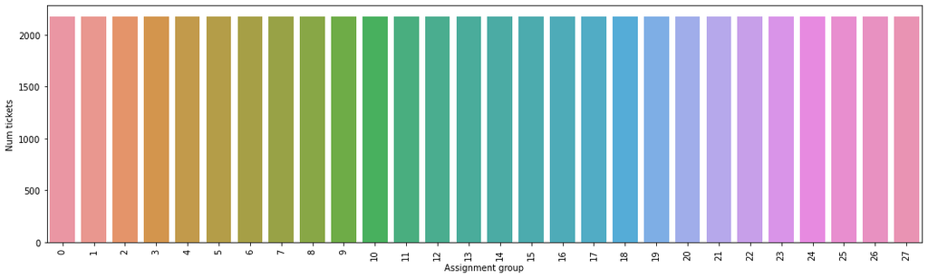

```python
# Visualize the distribution
dist = train[['Assignment group', 'proc_final_description']].groupby(by='Assignment group').agg('count') \
    .rename(columns={'proc_final_description': 'Num tickets'}).reset_index().sort_values(by='Num tickets', ascending=False)

plt.subplots(figsize = (18,5))
plt.xticks(rotation=90)
sns.barplot(x='Assignment group', y='Num tickets', data=dist)
```

```python
X_train = train['proc_final_description']
y_train = train['Assignment group']
```

```python
# Fit and transform the vectorizer on train set
X_train_tfidf_trans = vectorizer.fit_transform(X_train)

# Have a look at vectorizer vocabulary
vectorizer.vocabulary_['skype meeting']
```

```
8200
```

```python
# Let's build a train a classifier on above data

# Define and train the model
classifier = MultinomialNB()
classifier.fit(X_train_tfidf_trans, y_train)

# transform the test set
X_test_tfidf_trans = vectorizer.transform(X_test)

# Make predictions
predicted = classifier.predict(X_test_tfidf_trans)
predicted_prob = classifier.predict_proba(X_test_tfidf_trans)
```

```python
## Accuracy, Precision, Recall
accuracy = metrics.accuracy_score(y_test, predicted)
auc = metrics.roc_auc_score(y_test, predicted_prob,
                            multi_class="ovr")
print("Accuracy:",  round(accuracy,2))
print("Auc:", round(auc,2))
print("Detail:")
print(metrics.classification_report(y_test, predicted))
```

```
Accuracy: 0.5
Auc: 0.92
Detail:
              precision    recall  f1-score   support

           0       0.85      0.46      0.59       931
           1       0.37      0.44      0.40        25
           2       0.69      0.58      0.63        74
           3       0.42      0.77      0.54        43
           4       0.27      0.46      0.34        35
           5       0.32      0.84      0.46        25
           6       0.26      1.00      0.41        20
           7       0.33      0.50      0.40        26
           8       0.28      0.52      0.36        64
           9       0.37      0.54      0.44        72
```

[output cut: 22 more lines]

```python
# Still no improvement overall
```

# Let's try only for top 10 groups

```python
X = data_top10['proc_final_description']
y = data_top10['Assignment group']

X_train, X_test, y_train, y_test = train_test_split(X, y, test_size=0.3, stratify=y, random_state=12)
```

```python
# initialize vectorizer with max vocab of 10000 words
vectorizer = feature_extraction.text.TfidfVectorizer(max_features=10000, ngram_range=(1,2))
```

```python
# Fit and transform the vectorizer on train set
X_train_tfidf_trans = vectorizer.fit_transform(X_train)

# Have a look at vectorizer vocabulary
vectorizer.vocabulary_['skype meeting']
```

```
7656
```

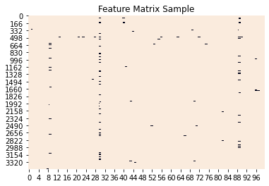

```python
# Visualize the feature matrix
sns.heatmap(X_train_tfidf_trans.todense()
            [:,np.random.randint(0,X_train_tfidf_trans.shape[1],100)]==0, vmin=0, vmax=1, cbar=False) \
    .set_title('Feature Matrix Sample')
```

```python
# Define and train the model
classifier = MultinomialNB()
classifier.fit(X_train_tfidf_trans, y_train)

# transform the test set
X_test_tfidf_trans = vectorizer.transform(X_test)

# Make predictions
predicted = classifier.predict(X_test_tfidf_trans)
predicted_prob = classifier.predict_proba(X_test_tfidf_trans)
```

```python
## Accuracy, Precision, Recall
accuracy = metrics.accuracy_score(y_test, predicted)
auc = metrics.roc_auc_score(y_test, predicted_prob,
                            multi_class="ovr")
print("Accuracy:",  round(accuracy,2))
print("Auc:", round(auc,2))
print("Detail:")
print(metrics.classification_report(y_test, predicted))
```

```
Accuracy: 0.72
Auc: 0.85
Detail:
              precision    recall  f1-score   support

           0       0.70      1.00      0.82       931
           1       0.79      0.20      0.32        74
           2       0.00      0.00      0.00        43
           3       1.00      0.06      0.11        35
           4       0.00      0.00      0.00        64
           5       0.75      0.25      0.38        72
           6       1.00      0.31      0.47        81
           7       0.00      0.00      0.00        35
           8       0.00      0.00      0.00        60
           9       0.96      0.83      0.89        96

    accuracy                           0.72      1491
   macro avg       0.52      0.27      0.30      1491
weighted avg       0.65      0.72      0.63      1491
```

```
C:\Users\Pulkit Malhotra\Anaconda3\lib\site-packages\sklearn\metrics\_classification.py:1221: UndefinedMetricWarning: Precision and F-score are ill-defined and being set to 0.0 in labels with no predicted samples. Use `zero_division` parameter to control this behavior.
  _warn_prf(average, modifier, msg_start, len(result))
```

# Let's try only for top 6 groups

```python
X = data_top6['proc_final_description']
y = data_top6['Assignment group']

X_train, X_test, y_train, y_test = train_test_split(X, y, test_size=0.3, stratify=y, random_state=12)
```

```python
# initialize vectorizer with max vocab of 10000 words
vectorizer = feature_extraction.text.TfidfVectorizer(max_features=10000, ngram_range=(1,2))
```

```python
# Fit and transform the vectorizer on train set
X_train_tfidf_trans = vectorizer.fit_transform(X_train)

# Have a look at vectorizer vocabulary
vectorizer.vocabulary_['skype meeting']
```

```
7815
```

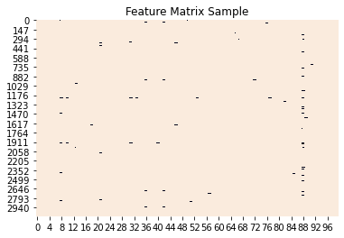

```python
# Visualize the feature matrix
sns.heatmap(X_train_tfidf_trans.todense()
            [:,np.random.randint(0,X_train_tfidf_trans.shape[1],100)]==0, vmin=0, vmax=1, cbar=False) \
    .set_title('Feature Matrix Sample')
```

```python
# Let's build a train a classifier on above data
# We will start with Multinomial Naive-Bayes
from sklearn.naive_bayes import MultinomialNB

# Define and train the model
classifier = MultinomialNB()
classifier.fit(X_train_tfidf_trans, y_train)

# transform the test set
X_test_tfidf_trans = vectorizer.transform(X_test)

# Make predictions
predicted = classifier.predict(X_test_tfidf_trans)
predicted_prob = classifier.predict_proba(X_test_tfidf_trans)
```

```python
## Accuracy, Precision, Recall
accuracy = metrics.accuracy_score(y_test, predicted)
auc = metrics.roc_auc_score(y_test, predicted_prob,
                            multi_class="ovr")
print("Accuracy:",  round(accuracy,2))
print("Auc:", round(auc,2))
print("Detail:")
print(metrics.classification_report(y_test, predicted))
```

```
Accuracy: 0.81
Auc: 0.88
Detail:
              precision    recall  f1-score   support

           0       0.80      1.00      0.89       931
           1       0.88      0.20      0.33        74
           2       0.00      0.00      0.00        64
           3       0.86      0.25      0.39        72
           4       1.00      0.35      0.51        81
           5       0.96      0.85      0.91        96

    accuracy                           0.81      1318
   macro avg       0.75      0.44      0.50      1318
weighted avg       0.79      0.81      0.76      1318
```

```
C:\Users\Pulkit Malhotra\Anaconda3\lib\site-packages\sklearn\metrics\_classification.py:1221: UndefinedMetricWarning: Precision and F-score are ill-defined and being set to 0.0 in labels with no predicted samples. Use `zero_division` parameter to control this behavior.
  _warn_prf(average, modifier, msg_start, len(result))
```

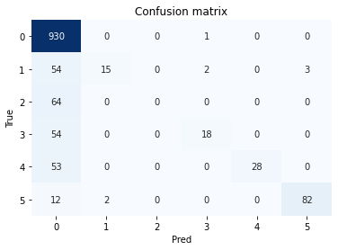

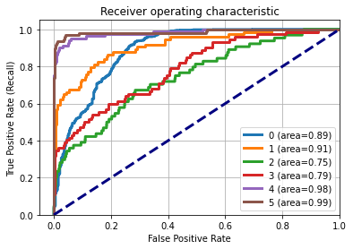

```python
classes = np.unique(y_test)
y_test_array = pd.get_dummies(y_test, drop_first=False).values

## Plot confusion matrix
cm = metrics.confusion_matrix(y_test, predicted)
fig, ax = plt.subplots()
sns.heatmap(cm, annot=True, fmt='d', ax=ax, cmap=plt.cm.Blues,
            cbar=False)
ax.set(xlabel="Pred", ylabel="True", xticklabels=classes,
       yticklabels=classes, title="Confusion matrix")
plt.yticks(rotation=0)

fig, ax = plt.subplots()

## Plot roc
for i in range(len(classes)):
    fpr, tpr, thresholds = metrics.roc_curve(y_test_array[:,i],
                           predicted_prob[:,i])
    ax.plot(fpr, tpr, lw=3,
              label='{0} (area={1:0.2f})'.format(classes[i],
                              metrics.auc(fpr, tpr))
               )
ax.plot([0,1], [0,1], color='navy', lw=3, linestyle='--')
ax.set(xlim=[-0.05,1.0], ylim=[0.0,1.05],
          xlabel='False Positive Rate',
          ylabel="True Positive Rate (Recall)",
          title="Receiver operating characteristic")
ax.legend(loc="lower right")
ax.grid(True)
```

### Word2Vec with Bi-LSTM on top 6 Groups

```python
import gensim

train_words = list()

for line in X_train:
    train_words.append(line.split())

#train word2vec model
model = gensim.models.Word2Vec(
    sentences=train_words,
    size=300,
    window=5,
    workers=4,
    min_count=1)

num_words = len(list(model.wv.vocab))
num_words
```

```
6315
```

```python
X_train
```

```
7023                             window account locked ad
4261                      pdf file get save freeze server
5988                telephony software software configure
4615                             id printer printer setup
2385                                     printer printing
                              ...
429     setup rechner ewel fnr hr thrydad consult cons...
707                         share mailbox update activity
56      unlock logon password receive please help unlo...
5466    circuit outage company eu gbr united kingdom d...
970     folder deletion drive receive could please hel...
Name: proc_final_description, Length: 3075, dtype: object
```

```python
model.wv.most_similar('job')
```

```
[('scheduler', 0.9989041090011597),
 ('fail', 0.99607914686203),
 ('bkbackup', 0.9958194494247437),
 ('abended', 0.9957460165023804),
 ('arc', 0.9947656393051147),
 ('oemcold', 0.9926097393035889),
 ('biaprod', 0.9915032386779785),
 ('prod', 0.990776538848877),
 ('hotf', 0.9898699522018433),
 ('bkwin', 0.9890618920326233)]
```

```python
model.wv.save_word2vec_format('w2v_emb_file_300.txt', binary=False)
```

```python
# Convert to numpy arrays
X_train = np.array(X_train)
X_test = np.array(X_test)
```

```python
# To help us decide the max length of the description to keep, we add a column having num_words
temp_df = pd.concat([pd.Series(X_train), pd.Series(y_train)], axis=1).rename(columns={0:'description', 1:'group'})
temp_df['num_words'] = temp_df['description'].apply(lambda x: len(str(x).split()))
temp_df.head()
```

|  | description | Assignment group | num_words |
| --- | --- | --- | --- |
| 0 | window account locked ad | 0.0 | 4 |
| 1 | pdf file get save freeze server | 0.0 | 6 |
| 2 | telephony software software configure | 0.0 | 4 |
| 3 | id printer printer setup | 0.0 | 4 |
| 4 | printer printing | 0.0 | 2 |

```
C:\Users\Pulkit Malhotra\Anaconda3\lib\site-packages\seaborn\distributions.py:2551: FutureWarning: `distplot` is a deprecated function and will be removed in a future version. Please adapt your code to use either `displot` (a figure-level function with similar flexibility) or `histplot` (an axes-lev…
  warnings.warn(msg, FutureWarning)
```

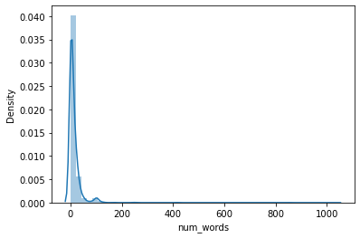

```python
# Visualize the distribution
sns.distplot(temp_df.num_words)
```

```python
temp_df.columns
```

```
Index(['description', 'Assignment group', 'num_words'], dtype='object')
```

```python
# Lets look at the mean number of words per assignment group

data_avg_length = pd.DataFrame(temp_df.groupby('Assignment group').agg('mean')['num_words']) \
    .rename(columns={'num_words': 'avg_num_words'})
data_ticket_cnt = pd.DataFrame(temp_df.groupby('Assignment group').agg('count')['num_words']) \
    .rename(columns={'num_words': 'ticket_cnt'})
data_avg_length.join(data_ticket_cnt).sort_values(by='avg_num_words', ascending=False)
```

| Assignment group | avg_num_words | ticket_cnt |
| --- | --- | --- |
| 1.0 | 11.889535 | 172 |
| 5.0 | 10.294643 | 224 |
| 0.0 | 9.824965 | 2171 |
| 4.0 | 8.248677 | 189 |
| 3.0 | 7.763314 | 169 |
| 2.0 | 6.073333 | 150 |

```python
# As we can see, the average is varying with the assignment group,
# it should be safe to keep truncate/pad the tickets at length of 100 words
max_len = 100
```

```python
# Create tokens for the description, we will use TF tokenizer
from tensorflow.keras.preprocessing.text import Tokenizer
tokenizer = Tokenizer()

# Fit on train texts and convert them to sequences
tokenizer.fit_on_texts(X_train) # X_train is np.array having training descriptions
X_train_sequences = tokenizer.texts_to_sequences(X_train)

# Convert the test texts to sequences
X_test_sequences = tokenizer.texts_to_sequences(X_test)
```

```python
# Pad the sequences with max length
from tensorflow.keras.preprocessing.sequence import pad_sequences

# Pad the sentences with 0 to mark them as unknown word
X_train_sequences_pad = pad_sequences(X_train_sequences, maxlen=max_len, padding='post', value=0)
X_test_sequences_pad = pad_sequences(X_test_sequences, maxlen=max_len, padding='post', value=0)

# Convert targets to numpy array
y_train = np.array(y_train)
y_test = np.array(y_test)
```

```python
# Create embedding matrix

embedding_size = 300

embeddings_index = {}
for o in open('w2v_emb_file_300.txt', encoding="utf8"):
    values = o.split()
    word = values[0]
    coefs = np.asarray(values[1:])
    embeddings_index[word] = coefs

# create a weight matrix for words in training docs
num_words = len(tokenizer.word_index)+1
embedding_matrix = np.zeros((num_words, embedding_size))

for word, i in tokenizer.word_index.items():
    if i > num_words:
        continue
    embedding_vector = embeddings_index.get(word)
    if embedding_vector is not None:
        embedding_matrix[i] = embedding_vector
```

```python
import tensorflow.keras as keras
from tensorflow.keras.models import Model
from tensorflow.keras.layers import LSTM, Embedding, Dense, Bidirectional, Input, Flatten, Dropout

inputs = Input(shape=(max_len,)) # Input layer
model = Embedding(num_words, embedding_size,
                  embeddings_initializer=keras.initializers.Constant(embedding_matrix),
                  trainable=True)(inputs)
model = Bidirectional(LSTM(units=500, dropout=0.2))(model) # Bi-directional LSTM layer
model = Flatten()(model) # Flatten
model = Dense(200, activation='relu')(model) # Dense layer 1
model = Dropout(0.2)(model) # Dropout 1
model = Dense(100, activation='relu')(model) # Dense layer 2
model = Dropout(0.2)(model) # Dropout 2
model = Dense(50, activation='relu')(model) # Dense layer 3
model = Dropout(0.2)(model) # Dropout 3
out = Dense(pd.Series(y_train).nunique(), activation='softmax')(model) # Sigmoid output layer

model = Model(inputs, out) # Complete model
```

```python
# Compile the model
model.compile(optimizer="adam", loss="sparse_categorical_crossentropy", metrics=["accuracy"]) # Compile the model
model.summary()
```

```
Model: "model"
_________________________________________________________________
Layer (type)                 Output Shape              Param #
=================================================================
input_1 (InputLayer)         [(None, 100)]             0
_________________________________________________________________
embedding (Embedding)        (None, 100, 300)          1894800
_________________________________________________________________
bidirectional (Bidirectional (None, 1000)              3204000
_________________________________________________________________
flatten (Flatten)            (None, 1000)              0
_________________________________________________________________
dense (Dense)                (None, 200)               200200
_________________________________________________________________
dropout (Dropout)            (None, 200)               0
_________________________________________________________________
dense_1 (Dense)              (None, 100)               20100
_________________________________________________________________
dropout_1 (Dropout)          (None, 100)               0
_________________________________________________________________
dense_2 (Dense)              (None, 50)                5050
_________________________________________________________________
dropout_2 (Dropout)          (None, 50)                0
_________________________________________________________________
dense_3 (Dense)              (None, 6)                 306
=================================================================
Total params: 5,324,456
Trainable params: 5,324,456
Non-trainable params: 0
_________________________________________________________________
```

```python
from tensorflow.keras.callbacks import ModelCheckpoint, ReduceLROnPlateau
checkpoint = ModelCheckpoint('model-{epoch:03d}-{val_accuracy:03f}.h5', verbose=1, monitor='val_accuracy',
                             save_best_only=True, mode='auto')
reduceLoss = ReduceLROnPlateau(monitor='val_loss', factor=0.2, patience=2, min_lr=0.0001)
callbacks = [checkpoint,reduceLoss]
```

```python
model.fit(X_train_sequences_pad, y_train, batch_size=128, epochs=10, callbacks=callbacks,
          validation_data=(X_test_sequences_pad, y_test), verbose=1)
```

```
Epoch 00001: val_accuracy improved from -inf to 0.75038, saving model to model-001-0.750379.h5
Epoch 00002: val_accuracy improved from 0.75038 to 0.77390, saving model to model-002-0.773900.h5
Epoch 00003: val_accuracy improved from 0.77390 to 0.77769, saving model to model-003-0.777693.h5
Epoch 00004: val_accuracy improved from 0.77769 to 0.80728, saving model to model-004-0.807284.h5
Epoch 00005: val_accuracy improved from 0.80728 to 0.83005, saving model to model-005-0.830046.h5
Epoch 00006: val_accuracy did not improve from 0.83005
Epoch 00007: val_accuracy improved from 0.83005 to 0.83991, saving model to model-007-0.839909.h5
Epoch 00008: val_accuracy improved from 0.83991 to 0.84067, saving model to model-008-0.840668.h5
Epoch 00009: val_accuracy did not improve from 0.84067
Epoch 00010: val_accuracy did not improve from 0.84067
```

```
<tensorflow.python.keras.callbacks.History at 0x2d4568cbd48>
```

```python
# Get predicted probabilities and predicted class

test_accuracy = model.evaluate(X_test_sequences_pad, y_test)[1]
y_pred_proba = model.predict(X_test_sequences_pad)
y_pred_class = [prob.argmax() for prob in y_pred_proba]

# Print accuracy, auc and classification report
print("Accuracy:",  round(test_accuracy,2))
print("Auc:", round(metrics.roc_auc_score(y_test, y_pred_proba, multi_class='ovr'),2))
print("Detail:")
print(metrics.classification_report(y_test, y_pred_class))
```

```
Accuracy: 0.84
Auc: 0.91
Detail:
              precision    recall  f1-score   support

           0       0.91      0.95      0.93       931
           1       0.62      0.53      0.57        74
           2       0.18      0.19      0.18        64
           3       0.44      0.32      0.37        72
           4       0.84      0.78      0.81        81
           5       0.93      0.86      0.90        96

    accuracy                           0.84      1318
   macro avg       0.65      0.60      0.63      1318
weighted avg       0.83      0.84      0.83      1318
```

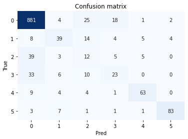

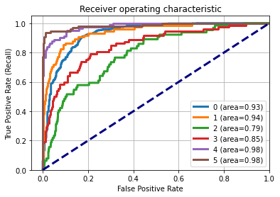

```python
classes = np.unique(y_test)
y_test_array = pd.get_dummies(y_test, drop_first=False).values

## Plot confusion matrix
cm = metrics.confusion_matrix(y_test, y_pred_class)
fig, ax = plt.subplots()
sns.heatmap(cm, annot=True, fmt='d', ax=ax, cmap=plt.cm.Blues,
            cbar=False)
ax.set(xlabel="Pred", ylabel="True", xticklabels=classes,
       yticklabels=classes, title="Confusion matrix")
plt.yticks(rotation=0)

fig, ax = plt.subplots()

## Plot roc
for i in range(len(classes)):
    fpr, tpr, thresholds = metrics.roc_curve(y_test_array[:,i],
                           y_pred_proba[:,i])
    ax.plot(fpr, tpr, lw=3,
              label='{0} (area={1:0.2f})'.format(classes[i],
                              metrics.auc(fpr, tpr))
               )
ax.plot([0,1], [0,1], color='navy', lw=3, linestyle='--')
ax.set(xlim=[-0.05,1.0], ylim=[0.0,1.05],
          xlabel='False Positive Rate',
          ylabel="True Positive Rate (Recall)",
          title="Receiver operating characteristic")
ax.legend(loc="lower right")
ax.grid(True)
```

# Glove with Bi-LSTM

```python
# As we can see, the average is varying with the assignment group,
# it should be safe to keep truncate/pad the tickets at length of 100 words
max_len = 100
```

```python
# Create tokens for the description, we will use TF tokenizer
from tensorflow.keras.preprocessing.text import Tokenizer
tokenizer = Tokenizer()

# Fit on train texts and convert them to sequences
tokenizer.fit_on_texts(X_train) # X_train is np.array having training descriptions
X_train_sequences = tokenizer.texts_to_sequences(X_train)

# Convert the test texts to sequences
X_test_sequences = tokenizer.texts_to_sequences(X_test)
```

```python
# Pad the sequences with max length
from tensorflow.keras.preprocessing.sequence import pad_sequences

# Pad the sentences with 0 to mark them as unknown word
X_train_sequences_pad = pad_sequences(X_train_sequences, maxlen=max_len, padding='post', value=0)
X_test_sequences_pad = pad_sequences(X_test_sequences, maxlen=max_len, padding='post', value=0)

# Convert targets to numpy array
y_train = np.array(y_train)
y_test = np.array(y_test)
```

```python
# Create embedding matrix

embedding_size = 300

embeddings_index = {}
for o in open('glove.6B.300d.txt', encoding="utf8"):
    values = o.split()
    word = values[0]
    coefs = np.asarray(values[1:])
    embeddings_index[word] = coefs

# create a weight matrix for words in training docs
num_words = len(tokenizer.word_index)+1
embedding_matrix = np.zeros((num_words, embedding_size))

for word, i in tokenizer.word_index.items():
    if i > num_words:
        continue
    embedding_vector = embeddings_index.get(word)
    if embedding_vector is not None:
        embedding_matrix[i] = embedding_vector
```

```python
import tensorflow.keras as keras
from tensorflow.keras.models import Model
from tensorflow.keras.layers import LSTM, Embedding, Dense, Bidirectional, Input, Flatten, Dropout

inputs = Input(shape=(max_len,)) # Input layer
model = Embedding(num_words, embedding_size,
                  embeddings_initializer=keras.initializers.Constant(embedding_matrix),
                  trainable=True)(inputs)
model = Bidirectional(LSTM(units=500, dropout=0.2))(model) # Bi-directional LSTM layer
model = Flatten()(model) # Flatten
model = Dense(200, activation='relu')(model) # Dense layer 1
model = Dropout(0.3)(model) # Dropout 1
model = Dense(100, activation='relu')(model) # Dense layer 2
model = Dropout(0.3)(model) # Dropout 2
model = Dense(50, activation='relu')(model) # Dense layer 3
model = Dropout(0.2)(model) # Dropout 3
out = Dense(pd.Series(y_train).nunique(), activation='softmax')(model) # Sigmoid output layer

model = Model(inputs, out) # Complete model
```

```python
# Compile the model
model.compile(optimizer="adam", loss="sparse_categorical_crossentropy", metrics=["accuracy"]) # Compile the model
model.summary()
```

```
Model: "model"
_________________________________________________________________
Layer (type)                 Output Shape              Param #
=================================================================
input_1 (InputLayer)         [(None, 100)]             0
_________________________________________________________________
embedding (Embedding)        (None, 100, 300)          1894800
_________________________________________________________________
bidirectional (Bidirectional (None, 1000)              3204000
_________________________________________________________________
flatten (Flatten)            (None, 1000)              0
_________________________________________________________________
dense (Dense)                (None, 200)               200200
_________________________________________________________________
dropout (Dropout)            (None, 200)               0
_________________________________________________________________
dense_1 (Dense)              (None, 100)               20100
_________________________________________________________________
dropout_1 (Dropout)          (None, 100)               0
_________________________________________________________________
dense_2 (Dense)              (None, 50)                5050
_________________________________________________________________
dropout_2 (Dropout)          (None, 50)                0
_________________________________________________________________
dense_3 (Dense)              (None, 6)                 306
=================================================================
Total params: 5,324,456
Trainable params: 5,324,456
Non-trainable params: 0
_________________________________________________________________
```

```python
from tensorflow.keras.callbacks import ModelCheckpoint, ReduceLROnPlateau
checkpoint = ModelCheckpoint('model-{epoch:03d}-{val_accuracy:03f}.h5', verbose=1, monitor='val_accuracy',
                             save_best_only=True, mode='auto')
reduceLoss = ReduceLROnPlateau(monitor='val_loss', factor=0.2, patience=2, min_lr=0.0001)
callbacks = [checkpoint,reduceLoss]
```

```python
model.fit(X_train_sequences_pad, y_train, batch_size=128, epochs=20, callbacks=callbacks,
          validation_data=(X_test_sequences_pad, y_test), verbose=1)
```

```
Epoch 00001: val_accuracy improved from -inf to 0.75797, saving model to model-001-0.757967.h5
Epoch 00002: val_accuracy improved from 0.75797 to 0.79894, saving model to model-002-0.798938.h5
Epoch 00003: val_accuracy improved from 0.79894 to 0.83839, saving model to model-003-0.838391.h5
Epoch 00004: val_accuracy improved from 0.83839 to 0.84598, saving model to model-004-0.845979.h5
Epoch 00005: val_accuracy improved from 0.84598 to 0.85281, saving model to model-005-0.852807.h5
Epoch 00006: val_accuracy improved from 0.85281 to 0.85964, saving model to model-006-0.859636.h5
Epoch 00007: val_accuracy did not improve from 0.85964
Epoch 00008: val_accuracy improved from 0.85964 to 0.86115, saving model to model-008-0.861153.h5
Epoch 00009: val_accuracy did not improve from 0.86115
Epoch 00010: val_accuracy improved from 0.86115 to 0.86191, saving model to model-010-0.861912.h5
Epoch 00011: val_accuracy did not improve from 0.86191
Epoch 00012: val_accuracy improved from 0.86191 to 0.86267, saving model to model-012-0.862671.h5
Epoch 00013: val_accuracy did not improve from 0.86267
Epoch 00014: val_accuracy improved from 0.86267 to 0.86419, saving model to model-014-0.864188.h5
Epoch 00015: val_accuracy improved from 0.86419 to 0.86722, saving model to model-015-0.867223.h5
Epoch 00016: val_accuracy did not improve from 0.86722
Epoch 00017: val_accuracy did not improve from 0.86722
Epoch 00018: val_accuracy did not improve from 0.86722
Epoch 00019: val_accuracy did not improve from 0.86722
Epoch 00020: val_accuracy did not improve from 0.86722
```

```
<tensorflow.python.keras.callbacks.History at 0x1bc5a0c0688>
```

```python
# Get predicted probabilities and predicted class
from sklearn import metrics
test_accuracy = model.evaluate(X_test_sequences_pad, y_test)[1]
y_pred_proba = model.predict(X_test_sequences_pad)
y_pred_class = [prob.argmax() for prob in y_pred_proba]

# Print accuracy, auc and classification report
print("Accuracy:",  round(test_accuracy,2))
print("Auc:", round(metrics.roc_auc_score(y_test, y_pred_proba, multi_class='ovr'),2))
print("Detail:")
print(metrics.classification_report(y_test, y_pred_class))
```

```
Accuracy: 0.86
Auc: 0.92
Detail:
              precision    recall  f1-score   support

           0       0.92      0.93      0.92       931
           1       0.69      0.62      0.65        74
           2       0.45      0.45      0.45        64
           3       0.54      0.53      0.53        72
           4       0.90      0.79      0.84        81
           5       0.87      0.88      0.87        96

    accuracy                           0.86      1318
   macro avg       0.73      0.70      0.71      1318
weighted avg       0.86      0.86      0.86      1318
```

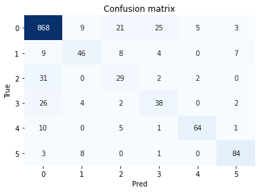

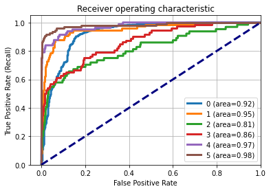

```python
classes = np.unique(y_test)
y_test_array = pd.get_dummies(y_test, drop_first=False).values

## Plot confusion matrix
cm = metrics.confusion_matrix(y_test, y_pred_class)
fig, ax = plt.subplots()
sns.heatmap(cm, annot=True, fmt='d', ax=ax, cmap=plt.cm.Blues,
            cbar=False)
ax.set(xlabel="Pred", ylabel="True", xticklabels=classes,
       yticklabels=classes, title="Confusion matrix")
plt.yticks(rotation=0)

fig, ax = plt.subplots()

## Plot roc
for i in range(len(classes)):
    fpr, tpr, thresholds = metrics.roc_curve(y_test_array[:,i],
                           y_pred_proba[:,i])
    ax.plot(fpr, tpr, lw=3,
              label='{0} (area={1:0.2f})'.format(classes[i],
                              metrics.auc(fpr, tpr))
               )
ax.plot([0,1], [0,1], color='navy', lw=3, linestyle='--')
ax.set(xlim=[-0.05,1.0], ylim=[0.0,1.05],
          xlabel='False Positive Rate',
          ylabel="True Positive Rate (Recall)",
          title="Receiver operating characteristic")
ax.legend(loc="lower right")
ax.grid(True)
```

# Fasttext Bi-LSTM

```python
import gensim

train_words = list()

for line in X_train:
    train_words.append(line.split())

#train word2vec model
model = gensim.models.FastText(
    sentences=train_words,
    size=300,
    window=5,
    workers=4,
    min_count=1)

num_words = len(list(model.wv.vocab))
num_words
```

```
6315
```

```python
model.wv.most_similar('job')
```

```
[('bk', 0.997759997844696),
 ('ob', 0.9946249723434448),
 ('jobxpkrg', 0.9883437156677246),
 ('fail', 0.9525641202926636),
 ('jojfufn', 0.9499300718307495),
 ('bob', 0.9439356327056885),
 ('fails', 0.9436606764793396),
 ('scheduler', 0.9410143494606018),
 ('dtjvhyob', 0.936641275882721),
 ('joerg', 0.9181241989135742)]
```

```python
model.wv.save_word2vec_format('fasttext_emb_file_300.txt', binary=False)
```

```python
# As we can see, the average is varying with the assignment group,
# it should be safe to keep truncate/pad the tickets at length of 100 words
max_len = 100
```

```python
# Create tokens for the description, we will use TF tokenizer
from tensorflow.keras.preprocessing.text import Tokenizer
tokenizer = Tokenizer()

# Fit on train texts and convert them to sequences
tokenizer.fit_on_texts(X_train) # X_train is np.array having training descriptions
X_train_sequences = tokenizer.texts_to_sequences(X_train)

# Convert the test texts to sequences
X_test_sequences = tokenizer.texts_to_sequences(X_test)
```

```python
# Pad the sequences with max length
from tensorflow.keras.preprocessing.sequence import pad_sequences

# Pad the sentences with 0 to mark them as unknown word
X_train_sequences_pad = pad_sequences(X_train_sequences, maxlen=max_len, padding='post', value=0)
X_test_sequences_pad = pad_sequences(X_test_sequences, maxlen=max_len, padding='post', value=0)

# Convert targets to numpy array
y_train = np.array(y_train)
y_test = np.array(y_test)
```

```python
# Create embedding matrix

embedding_size = 300

embeddings_index = {}
for o in open('fasttext_emb_file_300.txt', encoding="utf8"):
    values = o.split()
    word = values[0]
    coefs = np.asarray(values[1:])
    embeddings_index[word] = coefs

# create a weight matrix for words in training docs
num_words = len(tokenizer.word_index)+1
embedding_matrix = np.zeros((num_words, embedding_size))

for word, i in tokenizer.word_index.items():
    if i > num_words:
        continue
    embedding_vector = embeddings_index.get(word)
    if embedding_vector is not None:
        embedding_matrix[i] = embedding_vector
```

```python
import tensorflow.keras as keras
from tensorflow.keras.models import Model
from tensorflow.keras.layers import LSTM, Embedding, Dense, Bidirectional, Input, Flatten, Dropout

inputs = Input(shape=(max_len,)) # Input layer
model = Embedding(num_words, embedding_size,
                  embeddings_initializer=keras.initializers.Constant(embedding_matrix),
                  trainable=True)(inputs)
model = Bidirectional(LSTM(units=500, dropout=0.2))(model) # Bi-directional LSTM layer
model = Flatten()(model) # Flatten
model = Dense(200, activation='relu')(model) # Dense layer 1
model = Dropout(0.3)(model) # Dropout 1
model = Dense(100, activation='relu')(model) # Dense layer 2
model = Dropout(0.3)(model) # Dropout 2
model = Dense(50, activation='relu')(model) # Dense layer 3
model = Dropout(0.2)(model) # Dropout 3
out = Dense(pd.Series(y_train).nunique(), activation='softmax')(model) # Sigmoid output layer

model = Model(inputs, out) # Complete model
```

```python
# Compile the model
model.compile(optimizer="adam", loss="sparse_categorical_crossentropy", metrics=["accuracy"]) # Compile the model
model.summary()
```

```
Model: "model"
_________________________________________________________________
Layer (type)                 Output Shape              Param #
=================================================================
input_1 (InputLayer)         [(None, 100)]             0
_________________________________________________________________
embedding (Embedding)        (None, 100, 300)          1894800
_________________________________________________________________
bidirectional (Bidirectional (None, 1000)              3204000
_________________________________________________________________
flatten (Flatten)            (None, 1000)              0
_________________________________________________________________
dense (Dense)                (None, 200)               200200
_________________________________________________________________
dropout (Dropout)            (None, 200)               0
_________________________________________________________________
dense_1 (Dense)              (None, 100)               20100
_________________________________________________________________
dropout_1 (Dropout)          (None, 100)               0
_________________________________________________________________
dense_2 (Dense)              (None, 50)                5050
_________________________________________________________________
dropout_2 (Dropout)          (None, 50)                0
_________________________________________________________________
dense_3 (Dense)              (None, 6)                 306
=================================================================
Total params: 5,324,456
Trainable params: 5,324,456
Non-trainable params: 0
_________________________________________________________________
```

```python
from tensorflow.keras.callbacks import ModelCheckpoint, ReduceLROnPlateau
checkpoint = ModelCheckpoint('model-{epoch:03d}-{val_accuracy:03f}.h5', verbose=1, monitor='val_accuracy',
                             save_best_only=True, mode='auto')
reduceLoss = ReduceLROnPlateau(monitor='val_loss', factor=0.2, patience=2, min_lr=0.0001)
callbacks = [checkpoint,reduceLoss]
```

```python
model.fit(X_train_sequences_pad, y_train, batch_size=128, epochs=20, callbacks=callbacks,
          validation_data=(X_test_sequences_pad, y_test), verbose=1)
```

```
Epoch 00001: val_accuracy improved from -inf to 0.76555, saving model to model-001-0.765554.h5
Epoch 00002: val_accuracy improved from 0.76555 to 0.76859, saving model to model-002-0.768589.h5
Epoch 00003: val_accuracy improved from 0.76859 to 0.78300, saving model to model-003-0.783005.h5
Epoch 00004: val_accuracy improved from 0.78300 to 0.81184, saving model to model-004-0.811836.h5
Epoch 00005: val_accuracy improved from 0.81184 to 0.83308, saving model to model-005-0.833080.h5
Epoch 00006: val_accuracy did not improve from 0.83308
Epoch 00007: val_accuracy did not improve from 0.83308
Epoch 00008: val_accuracy improved from 0.83308 to 0.83536, saving model to model-008-0.835357.h5
Epoch 00009: val_accuracy did not improve from 0.83536
Epoch 00010: val_accuracy did not improve from 0.83536
Epoch 00011: val_accuracy improved from 0.83536 to 0.83991, saving model to model-011-0.839909.h5
Epoch 00012: val_accuracy did not improve from 0.83991
Epoch 00013: val_accuracy improved from 0.83991 to 0.84067, saving model to model-013-0.840668.h5
Epoch 00014: val_accuracy did not improve from 0.84067
Epoch 00015: val_accuracy did not improve from 0.84067
Epoch 00016: val_accuracy did not improve from 0.84067
Epoch 00017: val_accuracy did not improve from 0.84067
Epoch 00018: val_accuracy did not improve from 0.84067
Epoch 00019: val_accuracy did not improve from 0.84067
Epoch 00020: val_accuracy did not improve from 0.84067
```

```
<tensorflow.python.keras.callbacks.History at 0x23a7ee11b88>
```

```python
# Get predicted probabilities and predicted class
from sklearn import metrics
test_accuracy = model.evaluate(X_test_sequences_pad, y_test)[1]
y_pred_proba = model.predict(X_test_sequences_pad)
y_pred_class = [prob.argmax() for prob in y_pred_proba]

# Print accuracy, auc and classification report
print("Accuracy:",  round(test_accuracy,2))
print("Auc:", round(metrics.roc_auc_score(y_test, y_pred_proba, multi_class='ovr'),2))
print("Detail:")
print(metrics.classification_report(y_test, y_pred_class))
```

```
Accuracy: 0.83
Auc: 0.9
Detail:
              precision    recall  f1-score   support

           0       0.91      0.94      0.92       931
           1       0.65      0.54      0.59        74
           2       0.27      0.31      0.29        64
           3       0.52      0.31      0.39        72
           4       0.74      0.73      0.73        81
           5       0.88      0.88      0.88        96

    accuracy                           0.83      1318
   macro avg       0.66      0.62      0.63      1318
weighted avg       0.83      0.83      0.83      1318
```

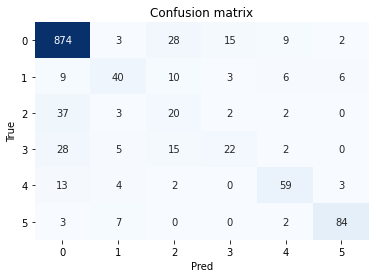

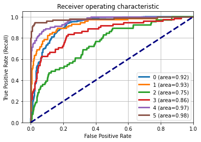

```python
classes = np.unique(y_test)
y_test_array = pd.get_dummies(y_test, drop_first=False).values

## Plot confusion matrix
cm = metrics.confusion_matrix(y_test, y_pred_class)
fig, ax = plt.subplots()
sns.heatmap(cm, annot=True, fmt='d', ax=ax, cmap=plt.cm.Blues,
            cbar=False)
ax.set(xlabel="Pred", ylabel="True", xticklabels=classes,
       yticklabels=classes, title="Confusion matrix")
plt.yticks(rotation=0)

fig, ax = plt.subplots()

## Plot roc
for i in range(len(classes)):
    fpr, tpr, thresholds = metrics.roc_curve(y_test_array[:,i],
                           y_pred_proba[:,i])
    ax.plot(fpr, tpr, lw=3,
              label='{0} (area={1:0.2f})'.format(classes[i],
                              metrics.auc(fpr, tpr))
               )
ax.plot([0,1], [0,1], color='navy', lw=3, linestyle='--')
ax.set(xlim=[-0.05,1.0], ylim=[0.0,1.05],
          xlabel='False Positive Rate',
          ylabel="True Positive Rate (Recall)",
          title="Receiver operating characteristic")
ax.legend(loc="lower right")
ax.grid(True)
```

# Elmo Encoding

```python
!pip install tensorflow_hub
import tensorflow_hub as hub
import tensorflow as tf
from sklearn import metrics
import tensorflow.keras as keras
from tensorflow.keras.models import Model
from tensorflow.keras.layers import LSTM, Embedding, Dense, Bidirectional, Input, Flatten, Dropout
```

```python
# As we can see, the average is varying with the assignment group,
# it should be safe to keep truncate/pad the tickets at length of 100 words
max_len = 100
```

```python
X_train_split=X_train.map(lambda x:x.split(" "))
X_test_split=X_test.map(lambda x:x.split(" "))
```

```python
# Pad the sequences with max length
from tensorflow.keras.preprocessing.sequence import pad_sequences

# Pad the sentences with 0 to mark them as unknown word
X_train_split_pad = pad_sequences(X_train_split, maxlen=max_len, dtype=object, padding='post', value='<PAD>')
X_test_split_pad = pad_sequences(X_test_split, maxlen=max_len, dtype=object, padding='post', value='<PAD>')

# Convert targets to numpy array
y_train = np.array(y_train)
y_test = np.array(y_test)
```

```python
X_train_pad = []
X_test_pad = []

for i in X_train_split_pad:
    X_train_pad.append(' '.join(i))

for i in X_test_split_pad:
    X_test_pad.append(' '.join(i))
```

```python
list_train = [X_train_pad[i:i+50] for i in range(0,len(X_train_pad),50)]
list_test = [X_test_pad[i:i+50] for i in range(0,len(X_test_pad),50)]
```

```python
from tqdm import tqdm
```

```python
elmo = hub.load("https://tfhub.dev/google/elmo/3")
```

[output not shown]

[output not shown]

```python
def elmo_vectors(x):
    embeddings=elmo.signatures["default"](tf.constant(x))["elmo"]
    return embeddings
```

```python
elmo_train = [elmo_vectors(x) for x in tqdm(list_train)]
```

```python
elmo_train[0].shape
```

```
TensorShape([50, 100, 1024])
```

```python
elmo_test = [elmo_vectors(x) for x in tqdm(list_test)]
```

```python
elmo_train_new = np.concatenate(elmo_train, axis = 0)
elmo_test_new = np.concatenate(elmo_test, axis = 0)
```

```python
elmo_train_new.shape
```

```
(3075, 100, 1024)
```

```python
import pickle
```

```python
pickle_out = open("elmo_train.pickle","wb")
pickle.dump(elmo_train_new, pickle_out)
pickle_out.close()

pickle_out = open("elmo_test.pickle","wb")
pickle.dump(elmo_train_new, pickle_out)
pickle_out.close()
```

```python
inputs = Input(shape=(max_len,1024,)) # Input layer
model = Bidirectional(LSTM(units=500, dropout=0.2))(inputs) # Bi-directional LSTM layer
model = Flatten()(model) # Flatten
model = Dense(200, activation='relu')(model) # Dense layer 1
model = Dropout(0.2)(model) # Dropout 1
model = Dense(100, activation='relu')(model) # Dense layer 2
model = Dropout(0.2)(model) # Dropout 2
model = Dense(50, activation='relu')(model) # Dense layer 3
model = Dropout(0.2)(model) # Dropout 3
out = Dense(pd.Series(y_train).nunique(), activation='softmax')(model) # Sigmoid output layer

model = Model(inputs, out) # Complete model
```

```python
# Compile the model
model.compile(optimizer="adam", loss="sparse_categorical_crossentropy", metrics=["accuracy"]) # Compile the model
model.summary()
```

```
Model: "model"
_________________________________________________________________
Layer (type)                 Output Shape              Param #
=================================================================
input_1 (InputLayer)         [(None, 100, 1024)]       0
_________________________________________________________________
bidirectional (Bidirectional (None, 1000)              6100000
_________________________________________________________________
flatten (Flatten)            (None, 1000)              0
_________________________________________________________________
dense (Dense)                (None, 200)               200200
_________________________________________________________________
dropout (Dropout)            (None, 200)               0
_________________________________________________________________
dense_1 (Dense)              (None, 100)               20100
_________________________________________________________________
dropout_1 (Dropout)          (None, 100)               0
_________________________________________________________________
dense_2 (Dense)              (None, 50)                5050
_________________________________________________________________
dropout_2 (Dropout)          (None, 50)                0
_________________________________________________________________
dense_3 (Dense)              (None, 6)                 306
=================================================================
Total params: 6,325,656
Trainable params: 6,325,656
Non-trainable params: 0
_________________________________________________________________
```

```python
from tensorflow.keras.callbacks import ModelCheckpoint, ReduceLROnPlateau
checkpoint = ModelCheckpoint('elmo-model-{epoch:03d}-{val_accuracy:03f}.h5', verbose=1, monitor='val_accuracy',
                             save_best_only=True, mode='auto')
reduceLoss = ReduceLROnPlateau(monitor='val_loss', factor=0.2, patience=2, min_lr=0.0001)
callbacks = [checkpoint,reduceLoss]
```

```python
model.fit(elmo_train_new, y_train, batch_size=128, epochs=15, callbacks=callbacks,
          validation_data=(elmo_test_new, y_test), verbose=1)
```

```
Epoch 00001: val_accuracy improved from -inf to 0.76555, saving model to elmo-model-001-0.765554.h5
Epoch 00002: val_accuracy improved from 0.76555 to 0.80956, saving model to elmo-model-002-0.809560.h5
Epoch 00003: val_accuracy improved from 0.80956 to 0.82094, saving model to elmo-model-003-0.820941.h5
Epoch 00004: val_accuracy did not improve from 0.82094
Epoch 00005: val_accuracy improved from 0.82094 to 0.82246, saving model to elmo-model-005-0.822458.h5
Epoch 00006: val_accuracy improved from 0.82246 to 0.83839, saving model to elmo-model-006-0.838391.h5
Epoch 00007: val_accuracy did not improve from 0.83839
Epoch 00008: val_accuracy did not improve from 0.83839
Epoch 00009: val_accuracy did not improve from 0.83839
Epoch 00010: val_accuracy improved from 0.83839 to 0.84370, saving model to elmo-model-010-0.843703.h5
Epoch 00011: val_accuracy did not improve from 0.84370
Epoch 00012: val_accuracy did not improve from 0.84370
Epoch 00013: val_accuracy did not improve from 0.84370
Epoch 00014: val_accuracy did not improve from 0.84370
Epoch 00015: val_accuracy did not improve from 0.84370
```

```
<tensorflow.python.keras.callbacks.History at 0x1f1a25d3ec8>
```

```python
# Get predicted probabilities and predicted class

test_accuracy = model.evaluate(elmo_test_new, y_test)[1]
y_pred_proba = model.predict(elmo_test_new)
y_pred_class = [prob.argmax() for prob in y_pred_proba]

# Print accuracy, auc and classification report
print("Accuracy:",  round(test_accuracy,2))
print("Auc:", round(metrics.roc_auc_score(y_test, y_pred_proba, multi_class='ovr'),2))
print("Detail:")
print(metrics.classification_report(y_test, y_pred_class))
```

```
Accuracy: 0.84
Auc: 0.91
Detail:
              precision    recall  f1-score   support

           0       0.88      0.94      0.91       931
           1       0.58      0.51      0.55        74
           2       0.37      0.11      0.17        64
           3       0.49      0.43      0.46        72
           4       0.87      0.81      0.84        81
           5       0.87      0.91      0.89        96

    accuracy                           0.84      1318
   macro avg       0.68      0.62      0.64      1318
weighted avg       0.81      0.84      0.82      1318
```

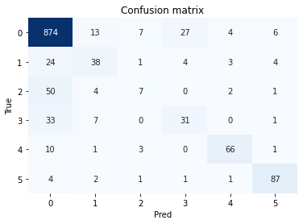

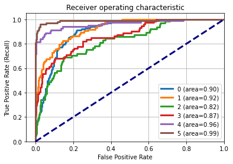

```python
classes = np.unique(y_test)
y_test_array = pd.get_dummies(y_test, drop_first=False).values

## Plot confusion matrix
cm = metrics.confusion_matrix(y_test, y_pred_class)
fig, ax = plt.subplots()
sns.heatmap(cm, annot=True, fmt='d', ax=ax, cmap=plt.cm.Blues,
            cbar=False)
ax.set(xlabel="Pred", ylabel="True", xticklabels=classes,
       yticklabels=classes, title="Confusion matrix")
plt.yticks(rotation=0)

fig, ax = plt.subplots()

## Plot roc
for i in range(len(classes)):
    fpr, tpr, thresholds = metrics.roc_curve(y_test_array[:,i],
                           y_pred_proba[:,i])
    ax.plot(fpr, tpr, lw=3,
              label='{0} (area={1:0.2f})'.format(classes[i],
                              metrics.auc(fpr, tpr))
               )
ax.plot([0,1], [0,1], color='navy', lw=3, linestyle='--')
ax.set(xlim=[-0.05,1.0], ylim=[0.0,1.05],
          xlabel='False Positive Rate',
          ylabel="True Positive Rate (Recall)",
          title="Receiver operating characteristic")
ax.legend(loc="lower right")
ax.grid(True)
```

# BERT

```python
import tensorflow_text as text
```

```python
# Encoders(L-2)/Embeddings(H-128)/Attention Heads(A-2)
tfhub_handle_encoder = "https://tfhub.dev/tensorflow/small_bert/bert_en_uncased_L-2_H-128_A-2/1"
tfhub_handle_preprocess = "https://tfhub.dev/tensorflow/bert_en_uncased_preprocess/2"
```

```python
def build_classifier_model():
  text_input = tf.keras.layers.Input(shape=(), dtype=tf.string, name='text')
  preprocessing_layer = hub.KerasLayer(tfhub_handle_preprocess, name='preprocessing')
  encoder_inputs = preprocessing_layer(text_input)
  encoder = hub.KerasLayer(tfhub_handle_encoder, trainable=True, name='BERT_encoder')
  outputs = encoder(encoder_inputs)
  net = outputs['pooled_output']
  net = tf.keras.layers.Dropout(0.1)(net)
  net = tf.keras.layers.Dense(pd.Series(y_train).nunique(), activation='softmax', name='classifier')(net)
  return tf.keras.Model(text_input, net)
```

```python
model = build_classifier_model()
```

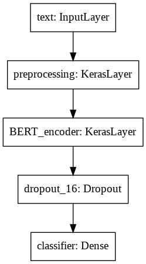

```python
tf.keras.utils.plot_model(model)
```

```python
# Compile the model
model.compile(optimizer="adam", loss="sparse_categorical_crossentropy", metrics=["accuracy"]) # Compile the model
model.summary()
```

```
Model: "model_12"
__________________________________________________________________________________________________
Layer (type)                    Output Shape         Param #     Connected to
==================================================================================================
text (InputLayer)               [(None,)]            0
__________________________________________________________________________________________________
preprocessing (KerasLayer)      {'input_word_ids': ( 0           text[0][0]
__________________________________________________________________________________________________
BERT_encoder (KerasLayer)       {'encoder_outputs':  4385921     preprocessing[0][0]
                                                                 preprocessing[0][1]
                                                                 preprocessing[0][2]
__________________________________________________________________________________________________
dropout_16 (Dropout)            (None, 128)          0           BERT_encoder[0][3]
__________________________________________________________________________________________________
classifier (Dense)              (None, 6)            774         dropout_16[0][0]
==================================================================================================
Total params: 4,386,695
Trainable params: 4,386,694
Non-trainable params: 1
__________________________________________________________________________________________________
```

```python
from tensorflow.keras.callbacks import ModelCheckpoint, ReduceLROnPlateau
checkpoint = ModelCheckpoint('bert-L-2_H-128_A-2-model-{epoch:03d}-{val_accuracy:03f}.h5', verbose=1, monitor='val_accuracy',
                             save_best_only=True, mode='auto')
reduceLoss = ReduceLROnPlateau(monitor='val_loss', factor=0.2, patience=2, min_lr=0.0001)
callbacks = [checkpoint,reduceLoss]
```

```python
model.fit(X_train, y_train, batch_size=128, epochs=20, callbacks=callbacks,
          validation_data=(X_test, y_test), verbose=1)
```

```
Epoch 00001: val_accuracy improved from -inf to 0.78089, saving model to bert-L-2_H-128_A-2-model-001-0.780895.h5

Epoch 00002: val_accuracy improved from 0.78089 to 0.84306, saving model to bert-L-2_H-128_A-2-model-002-0.843063.h5

Epoch 00003: val_accuracy did not improve from 0.84306

Epoch 00004: val_accuracy did not improve from 0.84306

Epoch 00005: val_accuracy improved from 0.84306 to 0.86353, saving model to bert-L-2_H-128_A-2-model-005-0.863533.h5

Epoch 00006: val_accuracy did not improve from 0.86353

Epoch 00007: val_accuracy did not improve from 0.86353

Epoch 00008: val_accuracy improved from 0.86353 to 0.86657, saving model to bert-L-2_H-128_A-2-model-008-0.866566.h5

Epoch 00009: val_accuracy did not improve from 0.86657

Epoch 00010: val_accuracy did not improve from 0.86657

Epoch 00011: val_accuracy did not improve from 0.86657

Epoch 00012: val_accuracy did not improve from 0.86657

Epoch 00013: val_accuracy did not improve from 0.86657

Epoch 00014: val_accuracy did not improve from 0.86657

Epoch 00015: val_accuracy did not improve from 0.86657

Epoch 00016: val_accuracy did not improve from 0.86657

Epoch 00017: val_accuracy did not improve from 0.86657

Epoch 00018: val_accuracy did not improve from 0.86657

Epoch 00019: val_accuracy did not improve from 0.86657

Epoch 00020: val_accuracy did not improve from 0.86657
```

```
<tensorflow.python.keras.callbacks.History at 0x7f1b5784f5f8>
```

```python
model=load_model('bert-L-2_H-128_A-2-model-008-0.866566.h5',custom_objects={'KerasLayer':hub.KerasLayer})
```

[output not shown]

[output not shown]

[output not shown]

[output not shown]

```python
# Get predicted probabilities and predicted class

test_accuracy = model.evaluate(X_test, y_test)[1]
y_pred_proba = model.predict(X_test)
y_pred_class = [prob.argmax() for prob in y_pred_proba]

# Print accuracy, auc and classification report
print("Accuracy:",  round(test_accuracy,2))
print("Auc:", round(metrics.roc_auc_score(y_test, y_pred_proba, multi_class='ovr'),2))
print("Detail:")
print(metrics.classification_report(y_test, y_pred_class))
```

```
Accuracy: 0.87
Auc: 0.91
Detail:
              precision    recall  f1-score   support

           0       0.90      0.95      0.93       931
           1       0.75      0.61      0.67        74
           2       0.53      0.42      0.47        64
           3       0.62      0.49      0.55        72
           4       0.84      0.84      0.84        82
           5       0.94      0.84      0.89        96

    accuracy                           0.87      1319
   macro avg       0.76      0.69      0.72      1319
weighted avg       0.86      0.87      0.86      1319
```

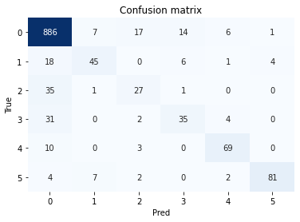

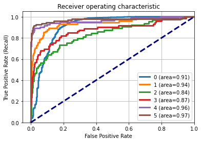

```python
classes = np.unique(y_test)
y_test_array = pd.get_dummies(y_test, drop_first=False).values

## Plot confusion matrix
cm = metrics.confusion_matrix(y_test, y_pred_class)
fig, ax = plt.subplots()
sns.heatmap(cm, annot=True, fmt='d', ax=ax, cmap=plt.cm.Blues,
            cbar=False)
ax.set(xlabel="Pred", ylabel="True", xticklabels=classes,
       yticklabels=classes, title="Confusion matrix")
plt.yticks(rotation=0)

fig, ax = plt.subplots()

## Plot roc
for i in range(len(classes)):
    fpr, tpr, thresholds = metrics.roc_curve(y_test_array[:,i],
                           y_pred_proba[:,i])
    ax.plot(fpr, tpr, lw=3,
              label='{0} (area={1:0.2f})'.format(classes[i],
                              metrics.auc(fpr, tpr))
               )
ax.plot([0,1], [0,1], color='navy', lw=3, linestyle='--')
ax.set(xlim=[-0.05,1.0], ylim=[0.0,1.05],
          xlabel='False Positive Rate',
          ylabel="True Positive Rate (Recall)",
          title="Receiver operating characteristic")
ax.legend(loc="lower right")
ax.grid(True)
```

###### Use sequence_output from BERT instead of pooled_output on resampled data:

```python
from tensorflow.keras.layers import TimeDistributed,ReLU,BatchNormalization
from tensorflow.keras.regularizers import L2
from imblearn.over_sampling import RandomOverSampler
```

```python
ros=RandomOverSampler(sampling_strategy='not majority', random_state=7)
X_train,y_train=ros.fit_resample(np.array(X_train).reshape(-1, 1),y_train)
```

```python
X_train=np.squeeze(X_train)
```

```python
seed=7

def build_classifier_model():
  text_input = tf.keras.layers.Input(shape=(), dtype=tf.string, name='text')
  preprocessing_layer = hub.KerasLayer(tfhub_handle_preprocess, name='preprocessing')
  encoder_inputs = preprocessing_layer(text_input)
  encoder = hub.KerasLayer(tfhub_handle_encoder, trainable=True, name='BERT_encoder')
  outputs = encoder(encoder_inputs)
  net = outputs['sequence_output']
  #model = Bidirectional(LSTM(units=128, dropout=0.2,activation='relu',return_sequences=True))(net) # Bi-directional LSTM layer
  model = TimeDistributed(Dense(units=64,name='Time_Distributed_Dense_Layer_1',kernel_regularizer=L2(l2=0.001)))(net)
  model = TimeDistributed(Dropout(rate=0.2,seed=seed))(model)
  model = TimeDistributed(BatchNormalization(axis=-1, momentum=0.99,name='Time_Distributed_Batch_Norm_Layer_1'))(model)
  model = TimeDistributed(ReLU())(model)
  model = TimeDistributed(Dense(units=32,name='Time_Distributed_Dense_Layer_2',kernel_regularizer=L2(l2=0.001)))(model)
  model = TimeDistributed(Dropout(rate=0.2,seed=seed))(model)
  model = TimeDistributed(BatchNormalization(axis=-1, momentum=0.99,name='Time_Distributed_Batch_Norm_Layer_2'))(model)
  model = TimeDistributed(ReLU())(model)
  model = Flatten()(model) # Flatten
  model = Dense(64, activation='relu')(model) # Dense layer 3
  model = Dropout(0.2)(model) # Dropout 3
  out = Dense(pd.Series(y_train).nunique(), activation='softmax')(model)
  return tf.keras.Model(text_input, out)
```

```python
model = build_classifier_model()
```

[output not shown]

[output not shown]

[output not shown]

[output not shown]

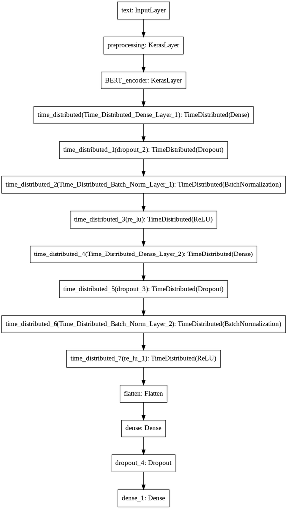

```python
tf.keras.utils.plot_model(model)
```

```python
# Compile the model
model.compile(optimizer="adam", loss="sparse_categorical_crossentropy", metrics=["accuracy"]) # Compile the model
model.summary()
```

```
Model: "model_2"
__________________________________________________________________________________________________
Layer (type)                    Output Shape         Param #     Connected to
==================================================================================================
text (InputLayer)               [(None,)]            0
__________________________________________________________________________________________________
preprocessing (KerasLayer)      {'input_word_ids': ( 0           text[0][0]
__________________________________________________________________________________________________
BERT_encoder (KerasLayer)       {'pooled_output': (N 4385921     preprocessing[0][0]
                                                                 preprocessing[0][1]
                                                                 preprocessing[0][2]
__________________________________________________________________________________________________
time_distributed_16 (TimeDistri (None, 128, 64)      8256        BERT_encoder[0][4]
__________________________________________________________________________________________________
time_distributed_17 (TimeDistri (None, 128, 64)      0           time_distributed_16[0][0]
__________________________________________________________________________________________________
time_distributed_18 (TimeDistri (None, 128, 64)      256         time_distributed_17[0][0]
__________________________________________________________________________________________________
time_distributed_19 (TimeDistri (None, 128, 64)      0           time_distributed_18[0][0]
__________________________________________________________________________________________________
time_distributed_20 (TimeDistri (None, 128, 32)      2080        time_distributed_19[0][0]
__________________________________________________________________________________________________
time_distributed_21 (TimeDistri (None, 128, 32)      0           time_distributed_20[0][0]
__________________________________________________________________________________________________
time_distributed_22 (TimeDistri (None, 128, 32)      128         time_distributed_21[0][0]
__________________________________________________________________________________________________
time_distributed_23 (TimeDistri (None, 128, 32)      0           time_distributed_22[0][0]
__________________________________________________________________________________________________
flatten_2 (Flatten)             (None, 4096)         0           time_distributed_23[0][0]
__________________________________________________________________________________________________
dense_4 (Dense)                 (None, 64)           262208      flatten_2[0][0]
__________________________________________________________________________________________________
dropout_8 (Dropout)             (None, 64)           0           dense_4[0][0]
__________________________________________________________________________________________________
dense_5 (Dense)                 (None, 6)            390         dropout_8[0][0]
==================================================================================================
Total params: 4,659,239
Trainable params: 4,659,046
Non-trainable params: 193
__________________________________________________________________________________________________
```

```python
from tensorflow.keras.callbacks import ModelCheckpoint, ReduceLROnPlateau
checkpoint = ModelCheckpoint('bert-resample-seqout-L-2_H-128_A-2-model-{epoch:03d}-{val_accuracy:03f}.h5', verbose=1, monitor='val_accuracy',
                             save_best_only=True, mode='auto')
reduceLoss = ReduceLROnPlateau(monitor='val_loss', factor=0.2, patience=2, min_lr=0.0001)
callbacks = [checkpoint,reduceLoss]
```

```python
model.fit(X_train, y_train, batch_size=128, epochs=20, callbacks=callbacks,
          validation_data=(X_test, y_test), verbose=1)
```

```
Epoch 00001: val_accuracy improved from -inf to 0.82866, saving model to bert-resample-seqout-L-2_H-128_A-2-model-001-0.828658.h5

Epoch 00002: val_accuracy improved from 0.82866 to 0.86050, saving model to bert-resample-seqout-L-2_H-128_A-2-model-002-0.860500.h5

Epoch 00003: val_accuracy did not improve from 0.86050

Epoch 00004: val_accuracy improved from 0.86050 to 0.87036, saving model to bert-resample-seqout-L-2_H-128_A-2-model-004-0.870356.h5

Epoch 00005: val_accuracy improved from 0.87036 to 0.87111, saving model to bert-resample-seqout-L-2_H-128_A-2-model-005-0.871114.h5

Epoch 00006: val_accuracy did not improve from 0.87111

Epoch 00007: val_accuracy improved from 0.87111 to 0.87642, saving model to bert-resample-seqout-L-2_H-128_A-2-model-007-0.876422.h5

Epoch 00008: val_accuracy did not improve from 0.87642

Epoch 00009: val_accuracy improved from 0.87642 to 0.87794, saving model to bert-resample-seqout-L-2_H-128_A-2-model-009-0.877938.h5

Epoch 00010: val_accuracy did not improve from 0.87794

Epoch 00011: val_accuracy did not improve from 0.87794

Epoch 00012: val_accuracy did not improve from 0.87794

Epoch 00013: val_accuracy did not improve from 0.87794

Epoch 00014: val_accuracy did not improve from 0.87794

Epoch 00015: val_accuracy did not improve from 0.87794

Epoch 00016: val_accuracy did not improve from 0.87794

Epoch 00017: val_accuracy did not improve from 0.87794

Epoch 00018: val_accuracy did not improve from 0.87794

Epoch 00019: val_accuracy did not improve from 0.87794

Epoch 00020: val_accuracy did not improve from 0.87794
```

```
<tensorflow.python.keras.callbacks.History at 0x7fef6cec1780>
```

```python
model.load_weights('/content/bert-resample-seqout-L-2_H-128_A-2-model-009-0.877938.h5')
```

```python
# Get predicted probabilities and predicted class

test_accuracy = model.evaluate(X_test, y_test)[1]
y_pred_proba = model.predict(X_test)
y_pred_class = [prob.argmax() for prob in y_pred_proba]

# Print accuracy, auc and classification report
print("Accuracy:",  round(test_accuracy,2))
print("Auc:", round(metrics.roc_auc_score(y_test, y_pred_proba, multi_class='ovr'),2))
print("Detail:")
print(metrics.classification_report(y_test, y_pred_class))
```

```
Accuracy: 0.88
Auc: 0.92
Detail:
              precision    recall  f1-score   support

           0       0.89      0.97      0.93       931
           1       0.88      0.57      0.69        74
           2       0.63      0.41      0.50        64
           3       0.72      0.50      0.59        72
           4       0.93      0.82      0.87        82
           5       0.90      0.90      0.90        96

    accuracy                           0.88      1319
   macro avg       0.82      0.69      0.74      1319
weighted avg       0.87      0.88      0.87      1319
```

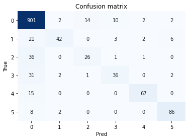

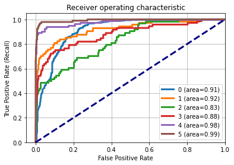

```python
classes = np.unique(y_test)
y_test_array = pd.get_dummies(y_test, drop_first=False).values

## Plot confusion matrix
cm = metrics.confusion_matrix(y_test, y_pred_class)
fig, ax = plt.subplots()
sns.heatmap(cm, annot=True, fmt='d', ax=ax, cmap=plt.cm.Blues,
            cbar=False)
ax.set(xlabel="Pred", ylabel="True", xticklabels=classes,
       yticklabels=classes, title="Confusion matrix")
plt.yticks(rotation=0)

fig, ax = plt.subplots()

## Plot roc
for i in range(len(classes)):
    fpr, tpr, thresholds = metrics.roc_curve(y_test_array[:,i],
                           y_pred_proba[:,i])
    ax.plot(fpr, tpr, lw=3,
              label='{0} (area={1:0.2f})'.format(classes[i],
                              metrics.auc(fpr, tpr))
               )
ax.plot([0,1], [0,1], color='navy', lw=3, linestyle='--')
ax.set(xlim=[-0.05,1.0], ylim=[0.0,1.05],
          xlabel='False Positive Rate',
          ylabel="True Positive Rate (Recall)",
          title="Receiver operating characteristic")
ax.legend(loc="lower right")
ax.grid(True)
```